# P5_Underreporting_Pfizer_Covid_Vaccine

Dominik Frei

08.04.2022 - 21.04.2022

# 1 Abstract

In this work I tried to find factors that might have influenced how many adverse events per dose administered where reported to the FDA that are related with the Pfizer Corona Vaccine. I looked at the time period since the launch of the vaccine until the end of 2021 in the USA.  
I used data from the FAERS database (Database containing information about reported cases of Adverse Events with Medicinal Products; FDA publishes this data and I had previously set up a MySQL database with all the reports from 2020 and 2021) and some datasets concerning covid vaccinations and numbers of cases and deaths, which where published by the US government.  
First I did some exploratory data analysis, where among other things, I tried to find out if there where more cases with the second administered dose then with the first one.  
Then I fitted some linear regression models (simple, multiple and for an exponential relationship) to find possible correlations with the number of cases reported per dose administered.  
The only finding was that the number of cases reported per dose administered decreased over time (probably in an exponential decay).

## 1.1 Resources

- FAERS Database: years 2020 and 2021
- dataset concerning Covid vaccines in the US: https://data.cdc.gov/Vaccinations/COVID-19-Vaccinations-in-the-United-States-Jurisdi/unsk-b7fc, accessed: 08.04.2022
- dataset concerning Covid cases and deaths in the US: https://data.cdc.gov/Case-Surveillance/United-States-COVID-19-Cases-and-Deaths-by-State-o/9mfq-cb36, accessed on 14.04.2022

## 1.2 What I learned

- Processing datetime data in R
- Plotting with ggplot2
- Fitting simple and multiple linear models (including transformations before fit, for exponential model)
- Checking model assumptions for simple and multiple linear models

## 1.3 Duration

- MySQL: 0.5 h
- R: 37 h
- Other (writing etc.): 7 h

# 2 Introduction

Post marketing drug safety relies on spontaneous reports about adverse events with drugs. It is well established, that by far not all cases of such events are reported (there is underreporting) and that there is considerable variation in underreporting. For example there might be suddenly way more reports for a certain drug event pair, after there where reports about it in the media.  
The covid vaccines and related adverse events got a lot of media attention, especially in the beginning. Here I will look more closely at the Pfizer vaccine in the US and try to find out what factors might have influenced its underreporting.

# 3 Glossary

- Adverse Event: Negative event that might be related to use of a drug without a causal relation being suspected.
- ADR (Adverse Drug Reaction): Adverse Event where a causal relation to the drug is suspected (by the reporter or the investigator)
- Underreporting: Fact that many ADRs are not reported and are therefore missing from ADR databases.

# 4 Code

## 4.1 Set-up

Set up connection to FAERS Database in MySQL:

Library, MySQL connection and global code chunk options

```r
# load Library to execute MySQL statements from here
library(RMySQL)
# establish connection
faers <- dbConnect(RMySQL::MySQL(),dbname='faers',username='root',password='Password', host='localhost',port=3306)

knitr::opts_chunk$set(connection = "faers", echo = TRUE, eval = TRUE)
```

Increase buffersize in order to be able to work with big amounts of data in MySQL:

```sql
SET GLOBAL innodb_buffer_pool_size=2147483648;
```

Libraries and working directory

```r
library(tidyverse)
```

```
## Error : 'format_warning' is not an exported object from 'namespace:cli'
```

```r
library(knitr)

setwd("C:/Users/domin/Desktop/Dominik/DS/Projects/P4_Signal_Detection_Covid_Vaccines")
```

## 4.2 FAERS Database

In P3 I created a MySQL database, containing Adverse Event data from the FAERS Database published by the FDA.The created database contains three tables called:  
- general - drugs - reactions

In P4 I did some analysis with Data concerning the three Covid-19 vaccines, that are on the Market in the US (Pfizer, Moderna and Janssen).

In order to speed up the workflow I created tables for the all records related to one of these three vaccines and “nos” (not otherwise specified, meaning the product reported was “covid vaccine” or some similar term). These tables had been set up as follows:

```sql
--create temporary table covac_pfi_all
--select * from drugs
--where medicinalproduct in
--    (select * from covid_vac_pfi);
```

```sql
--create table covac_pfi_d
--select * from covac_pfi_all
--where drugcharacterization = 1;
```

## 4.3 Exploratory Data Analysis

### 4.3.1 ADR Data

The Pfizer vaccine is the Covid-19 vaccine that was administrated the most in the US.

For how many reports do we have data in the drugs table for Pfizer?

```sql
select count(distinct safetyreportid) from covac_pfi_d;
```

1 records

| count(distinct safetyreportid) |
| --- |
| 3002 |

For how many reports do we have data in the general table for Pfizer?

```sql
select count(distinct safetyreportid) from covac_pfi_g;
```

1 records

| count(distinct safetyreportid) |
| --- |
| 3002 |

How many records do we have in these tables?

```sql
select count(safetyreportid) from covac_pfi_d;
```

1 records

| count(safetyreportid) |
| --- |
| 3886 |

```sql
select count(safetyreportid) from covac_pfi_g;
```

1 records

| count(safetyreportid) |
| --- |
| 3495 |

The discrepancy in these numbers is due to the fact, that for some reports there are different versions available in the database and there is not necessarily the same number of records, per version in the two tables. For example if the patient had received two administrations of the vaccine, there are two records in the drugs table, while there is only one in the general table.

How many cases do we have for the US?

```sql
select count(distinct safetyreportid) from covac_pfi_g
where occurcountry = "US";
```

1 records

| count(distinct safetyreportid) |
| --- |
| 1121 |

Do we have records for all of these in the drugs table?

```sql
with cases_US as
        (select distinct safetyreportid from covac_pfi_g
        where occurcountry = "US")
select count(distinct safetyreportid) from covac_pfi_d
where safetyreportid in (select * from cases_US);
```

1 records

| count(distinct safetyreportid) |
| --- |
| 1121 |

Yes

Get all the administration dates for cases with Pfizer. Save the result as pfi_admdates

```sql
select d.safetyreportid, d.drugstartdate
from covac_pfi_d d join covac_pfi_g g on d.safetyreportid = g.safetyreportid
where g.occurcountry = "US";
```

How many cases do we have over time according to the drugstartdate

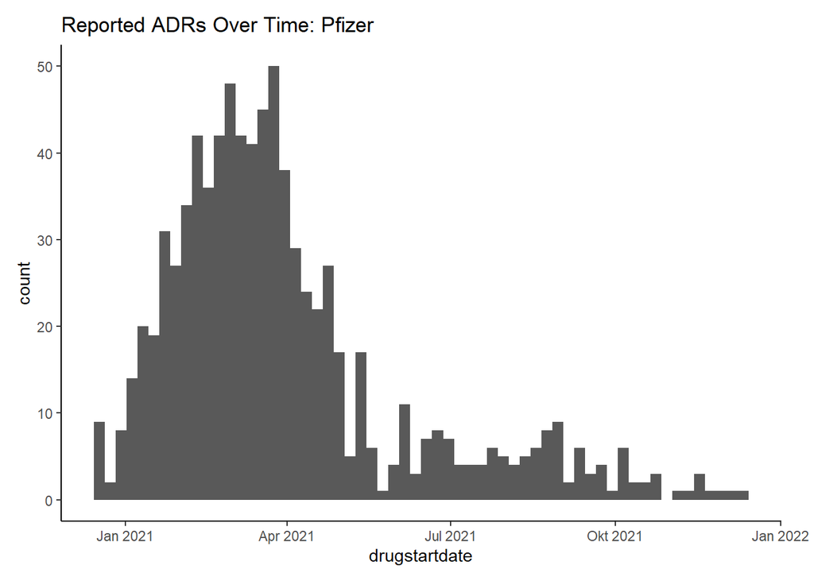

```r
#remove duplicate rows
pfi_admdates <- pfi_admdates %>% distinct(.keep_all = TRUE)
#drop rows containing NAs
pfi_admdates <- pfi_admdates %>% drop_na()
#filter for records where we have a complete date
pfi_admdates_f <- pfi_admdates %>% filter(nchar(drugstartdate) == 8)
#convert drugstartdate to Date format
pfi_admdates_f <- pfi_admdates_f %>% select(drugstartdate) %>% sapply(.,function(x){strptime(x, format = "%Y%m%d", tz = "UTC")}) %>%
    data.frame() %>% cbind(safetyreportid = pfi_admdates_f$safetyreportid, drugstartdate = .)
#filter out cases from before marketing (those are likely due to wrong data beeing reportes;
#but could also be cases from studies)
pfi_admdates_f <- pfi_admdates_f %>% filter(drugstartdate >= "2020-12-14")

#plot a histogram
hist_pfi_admdates <- pfi_admdates_f  %>% ggplot(aes(x = drugstartdate)) +
                                            geom_histogram(bins = 60) +
                                            theme_classic() +
                                            theme(plot.margin = margin(10,20,10,10)) +
                                            labs(title = "Reported ADRs Over Time: Pfizer")

hist_pfi_admdates
```

We have lots of cases from the first half of 2021. I assume that this is because there where more administrations at that time. We can later compare this to data about administration numbers in the US.

### 4.3.2 Covid-19 Administration Data US

Read in data about covid vaccines in the US (https://data.cdc.gov/Vaccinations/COVID-19-Vaccinations-in-the-United-States-Jurisdi/unsk-b7fc, accessed: 08.04.2022)

```r
covac_us <- read.csv("COVID-19_Vaccinations_in_the_United_States_Jurisdiction.csv")
```

We get a table with 82 variables and 31’000 records.

Why is this the case? We have Data for a certain amount of dates and for different locations:

```r
str(covac_us[,c(1,3)])
```

```
## 'data.frame':    31000 obs. of  2 variables:
##  $ Date    : Factor w/ 481 levels "01/01/2021","01/01/2022",..: 194 194 194 194 194 194 194 194 194 194 ...
##  $ Location: Factor w/ 66 levels "AK","AL","AR",..: 28 23 9 51 35 10 20 56 65 41 ...
```

There are 481 levels for Date and 66 Levels for Location:

```r
481*66
```

```
## [1] 31746
```

This would mean, that if we have the same number of entries per level, 746 records would be missing.

Are there less records for any of the locations?

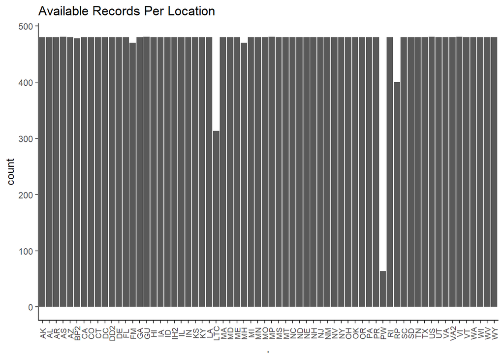

```r
covac_us$Location %>% data.frame() %>% ggplot(aes(.)) +
        geom_bar() +
        theme_classic() +
        theme(axis.text.x = element_text(angle = 90, hjust = 0.5, vjust = 0.5, size = 8)) +
        labs(title = "Available Records Per Location")
```

Yes. i.e. for “PW”, “LTC”, “RP”. RP stands for “Republic of Palau” and LTC for “Long Term Care”

Lets transform the Date Column to dates

```r
covac_us$Date <- covac_us$Date %>% as.Date(tryFormats = c("%m/%d/%Y"))

covac_us$Date %>% summary()
```

```
##         Min.      1st Qu.       Median         Mean      3rd Qu.         Max.
## "2020-12-13" "2021-04-12" "2021-08-09" "2021-08-09" "2021-12-07" "2022-04-07"
```

Look at the administration numbers of these three Locations and AK (as control, since it has the “normal” amount of records in the table)

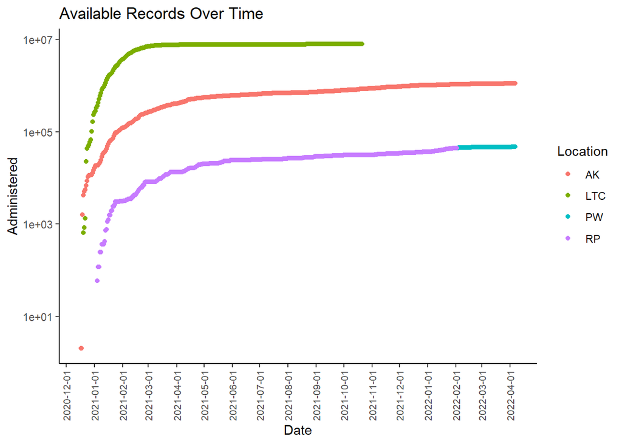

```r
covac_us[covac_us$Location %in% c("PW", "LTC", "RP", "AK") & covac_us$Administered != 0,] %>% ggplot(aes(x = Date, y = Administered, color = Location)) +
        geom_point() +
        theme_classic() +
        theme(axis.text.x = element_text(angle = 90, hjust = 0.5, vjust = 0.5, size = 8)) +
        scale_y_continuous(trans = "log10") +
        scale_x_date(breaks="month") +
        labs(title = "Available Records Over Time")
```

It looks like Data for LTC was no longer registered somewhere in autumn 2021. It also looks like the data for “RP” stops in February 2022 and “PW” “takes over” from it. So maybe they just changed the the shorthand name for the location.

Lets see when the data for the two starts / stops and with which values for Administered:

```r
covac_us[covac_us$Location == "RP", c("Date", "Administered")] %>% summary()
```

```
##       Date             Administered
##  Min.   :2020-12-30   Min.   :    0
##  1st Qu.:2021-04-08   1st Qu.:13972
##  Median :2021-07-17   Median :25416
##  Mean   :2021-07-17   Mean   :23398
##  3rd Qu.:2021-10-25   3rd Qu.:31592
##  Max.   :2022-02-02   Max.   :44526
```

```r
covac_us[covac_us$Location == "PW", c("Date", "Administered")] %>% summary()
```

```
##       Date             Administered
##  Min.   :2022-02-03   Min.   :44760
##  1st Qu.:2022-02-18   1st Qu.:46150
##  Median :2022-03-06   Median :46703
##  Mean   :2022-03-06   Mean   :46462
##  3rd Qu.:2022-03-22   3rd Qu.:46994
##  Max.   :2022-04-07   Max.   :47139
```

It seems very plausible, that the shorthand was changed from RP to PW (as the data starts one day after the other ends, and the values for administered are very close together)

There is a Location “US” which stands for United States. Does this “cumulate” all the data included in the other locations? Look at the latest data:

```r
covac_us %>% filter(Location == "US", Date == as.Date("2022-04-07")) %>% select(Administered)
```

```
##   Administered
## 1    563999093
```

```r
covac_us %>% filter(Location != "US", Date == as.Date("2022-04-07")) %>% select(Administered) %>% sum()
```

```
## [1] 579078678
```

No the sum of the other locations is bigger then the number for “US”.

```r
579078678 - 563999093
```

```
## [1] 15079585
```

The difference is 15 Mio. Is ther a single Location, with this number?

```r
covac_us %>% filter(Administered == 15079585)
```

No (output not shown). It must be several locations that are not included under US. I assume it is due to some double counts, and that some of the locations listed are not part of the US.

I will assume that Location = US from this data and occurcountry = US are equivalent.

Continue with the Data from Location = US. Create a graph for number of vaccinations per product over time:

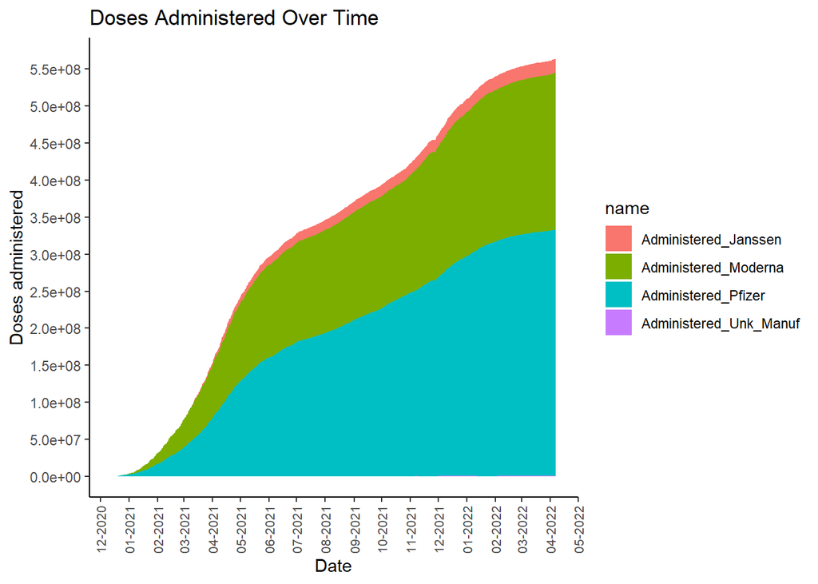

```r
#separate the data out
covac_us_tot <- covac_us %>% filter(Location == "US")
#transform and visualize data
covac_us_tot %>% select(Date, Administered_Unk_Manuf, Administered_Janssen, Administered_Moderna, Administered_Pfizer) %>%
        pivot_longer(cols = c(Administered_Unk_Manuf, Administered_Janssen, Administered_Moderna, Administered_Pfizer)) %>%
        ggplot(aes(x = Date, y = value, fill = name)) +
        geom_area() +
        theme_classic() +
        theme(axis.text.x = element_text(angle = 90, hjust = 0.5, vjust = 0.5, size = 8)) +
        scale_x_date(breaks="month", date_labels = "%m-%Y") +
        scale_y_continuous(n.breaks=20) +
        ylab("Doses administered") +
        labs(title = "Doses Administered Over Time")
```

Calculate the administered doses per day from the cumulated data for Pfizer:

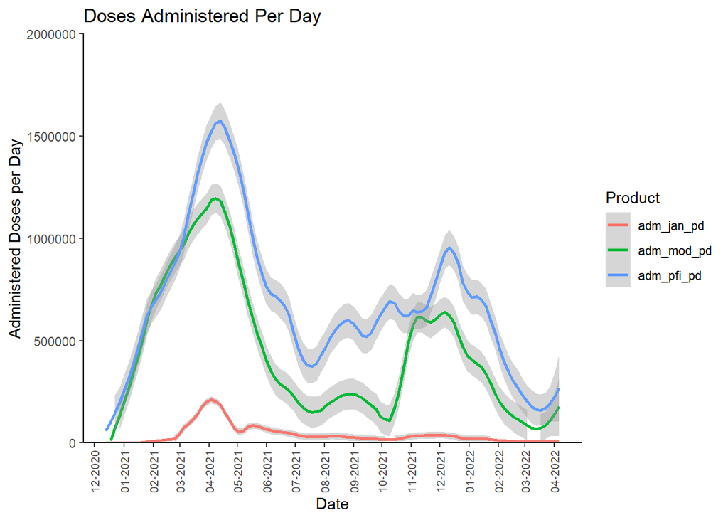

```r
#Pfizer
covac_pfi_pd <- covac_us_tot %>% select(Administered_Pfizer) %>% sapply(., function(x){abs(diff(x))}) %>% rbind(NA, .) %>%
    cbind(covac_us_tot[, c("Date", "Administered_Pfizer")], adm_pfi_pd = .)

colnames(covac_pfi_pd) <- c("Date", "adm_pfi_cum", "adm_pfi_pd")
#Moderna
covac_mod_pd <- covac_us_tot %>% select(Administered_Moderna) %>% sapply(., function(x){abs(diff(x))}) %>% rbind(NA, .) %>%
    cbind(covac_us_tot[, c("Date", "Administered_Moderna")], adm_mod_pd = .)

colnames(covac_mod_pd) <- c("Date", "adm_mod_cum", "adm_mod_pd")
#Janssen
covac_jan_pd <- covac_us_tot %>% select(Administered_Janssen) %>% sapply(., function(x){abs(diff(x))}) %>% rbind(NA, .) %>%
    cbind(covac_us_tot[, c("Date", "Administered_Janssen")], adm_jan_pd = .)

colnames(covac_jan_pd) <- c("Date", "adm_jan_cum", "adm_jan_pd")
#bind together
covac_all_pd <- cbind(covac_pfi_pd[,c("Date", "adm_pfi_pd")], adm_mod_pd = covac_mod_pd$adm_mod_pd, adm_jan_pd = covac_jan_pd$adm_jan_pd)

#plot
covac_all_pd %>% pivot_longer(cols = c("adm_pfi_pd", "adm_mod_pd", "adm_jan_pd")) %>%
    ggplot(aes(x = Date, y = value, color = name)) +
    geom_smooth(span = 0.15, n = 100, method = 'loess', formula = y ~ x) +
    theme_classic() +
    ylab(label = "Administered Doses per Day") +
    labs(color = "Product") +
    scale_y_continuous(expand = c(0, 0), limits = c(0,2000000)) +
    scale_x_date(breaks="month", date_labels = "%m-%Y") +
    theme(axis.text.x = element_text(angle = 90, hjust = 0.5, vjust = 0.5, size = 8)) +
    labs(title = "Doses Administered Per Day")
```

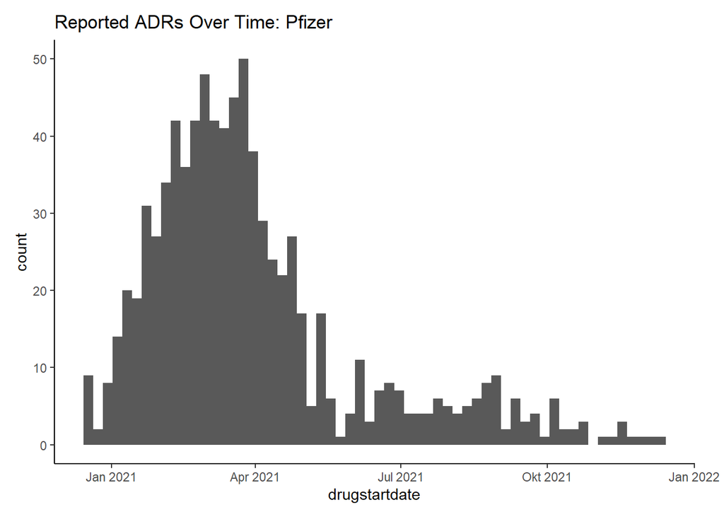

```r
#compare to number of cases received with Pfizer
hist_pfi_admdates
```

We we compare the number of administered doses of Pfizer with the received cases with Pfizer, we see that it has a similar shape, but is not necessarily proportional over the whole time.  
During the second peak of vaccinations (End of 2021) we dont see a proportionally big increase in case numbers.

We can now calculate the number of reports per administered doses for different months.

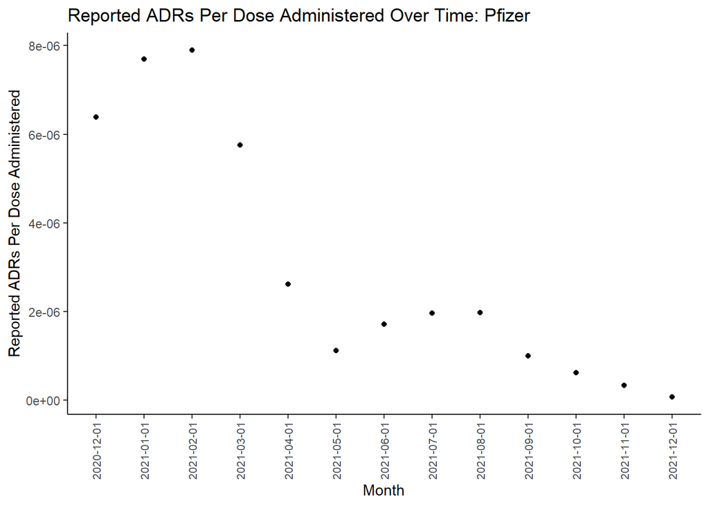

```r
#calculate cases per month (NOTE: we use the receive administration date to group them!)
pfi_cases_pm <- pfi_admdates_f %>% select(drugstartdate) %>% sapply(., cut.POSIXt, breaks = "month") %>% data.frame() %>% group_by(drugstartdate) %>% summarise(nr_cases_pm = length(drugstartdate))
#calculate doses administered per month
pfi_adm_pm <- covac_pfi_pd %>% select(Date, adm_pfi_pd) %>% drop_na() %>% mutate(Month = cut(Date, breaks = "month")) %>% group_by(Month) %>% summarise(., nr_adm_pm = sum(adm_pfi_pd))
#combine into one data frame (NOTE: We only have ADR data until end of 2021) and calculate cases per administration
pfi_cases_padm <- pfi_adm_pm %>% filter(as.Date(Month) < "2022-01-01") %>% cbind(., nr_cases_pm = pfi_cases_pm$nr_cases_pm) %>% mutate(., cases_padm = nr_cases_pm/nr_adm_pm)
#plot result
pfi_cases_padm %>% ggplot(aes(x = Month, y = cases_padm)) +
    geom_point() +
    theme_classic() +
    theme(axis.text.x = element_text(angle = 90, hjust = 0.5, vjust = 0.5, size = 8)) +
    ylab(label = "Reported ADRs Per Dose Administered") +
    labs(title = "Reported ADRs Per Dose Administered Over Time: Pfizer")
```

From this plot it looks like there was a downward trend over time for reported cases per dose administered for the Pfizer Vaccine.

Repeat the same but with “binning” per calender week:

```r
#calculate cases per week (NOTE: we use the receive administration date to group them!)
pfi_cases_pw <- pfi_admdates_f %>% select(drugstartdate) %>% sapply(., cut.POSIXt, breaks = "week") %>% data.frame() %>% group_by(drugstartdate) %>% summarise(nr_cases_pw = length(drugstartdate))
#calculate doses administered per week
pfi_adm_pw <- covac_pfi_pd %>% select(Date, adm_pfi_pd) %>% drop_na() %>% mutate(Week = cut(Date, breaks = "week")) %>% group_by(Week) %>% summarise(., nr_adm_pw = sum(adm_pfi_pd))
#in which weeks where reports received?
w_with_cases <- pfi_cases_pw %>% select(drugstartdate) %>% unique() %>% deframe()
w_with_cases %>% str()
```

```
##  Factor w/ 51 levels "2020-12-14","2020-12-21",..: 1 2 3 4 5 6 7 8 9 10 ...
```

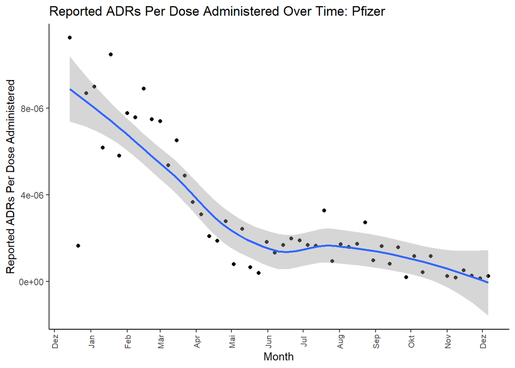

```r
#combine into one data frame (NOTE: We only have ADR data for certain weeks) and calculate cases per administration
pfi_cases_padm_w <- pfi_adm_pw %>% filter(Week %in% w_with_cases) %>% cbind(., nr_cases_pw = pfi_cases_pw$nr_cases_pw) %>% mutate(., cases_padm_w = nr_cases_pw/nr_adm_pw)
#reformat weeks to POSIXct
pfi_cases_padm_w <- pfi_cases_padm_w %>% select(Week) %>% sapply(., strptime, format = "%Y-%m-%d") %>% cbind(Week = ., pfi_cases_padm_w[,2:4])
#plot result
pfi_cases_padm_w %>% ggplot(aes(x = Week, y = cases_padm_w)) +
    geom_point() +
    geom_smooth(span = 0.8, n = 53, method = 'loess', formula = y ~ x) +
    theme_classic() +
    theme(axis.text.x = element_text(angle = 90, hjust = 0.5, vjust = 0.5, size = 8)) +
    ylab(label = "Reported ADRs Per Dose Administered") +
    xlab(label = "Month") +
    labs(title = "Reported ADRs Per Dose Administered Over Time: Pfizer") +
    scale_x_datetime(breaks="month", date_labels = "%b")
```

This plot shows a general downward trend over time as well. There is a small flattening/peak in summer 2021 (July/August). Maybe the second dose of the vaccine leads to more ADRs then the first dose. Therefore this peaks could be due to the fact that there might have been more second doses administered during this time.

### 4.3.3 Influence of Dose on Number of Reports

#### 4.3.3.1 Administration Data US

It is important to mention that the start dates in the ADR data can include several doses of the vaccine, even if not all the doses did lead to ADRs.

We can check the hypothesis above. We have a variable “Series_Complete_Pfizer”, which tells us when the second dose of Pfizer was received.

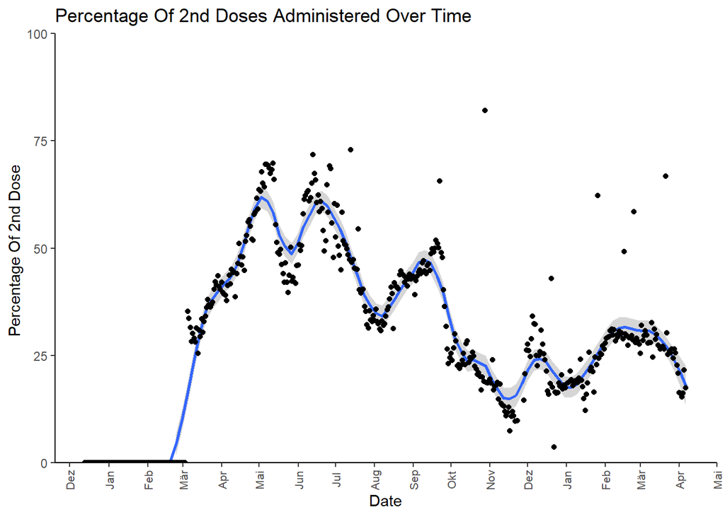

```r
#calculate administered 2nd doses per day and create dataframe
covac_pfi_pd_completed <- covac_us_tot %>% select(Series_Complete_Pfizer) %>% sapply(., function(x){abs(diff(x))}) %>% rbind(NA, .) %>%
    cbind(covac_us_tot[,c("Date", "Series_Complete_Pfizer")], adm_pfi_pd_2nd = .[,], adm_pfi_pd_tot = covac_pfi_pd$adm_pfi_pd) %>% .[,2:5]
#calculate percentage of 2nd doses
covac_pfi_pd_completed <- covac_pfi_pd_completed %>% mutate(., Perc_2nd = adm_pfi_pd_2nd/adm_pfi_pd_tot*100)

#plot
covac_pfi_pd_completed %>%
    ggplot(aes(x = Date, y = Perc_2nd)) +
    geom_smooth(span = 0.15, n = 100, method = 'loess', formula = y ~ x) +
    geom_point() +
    theme_classic() +
    ylab(label = "Percentage Of 2nd Dose ") +
    labs(color = "Product") +
    scale_y_continuous(expand = c(0, 0), limits = c(0,100)) +
    scale_x_date(breaks="month", date_labels = "%b") +
    theme(axis.text.x = element_text(angle = 90, hjust = 0.5, vjust = 0.5, size = 8)) +
    labs(title = "Percentage Of 2nd Doses Administered Over Time")
```

There is a local minimum in July/August. This contradicts the hypothesis above. It seems more likely that this small increase is due to chance or other factors (it could also be due to media attention).

It is important to note that this graph shows the percentage of second doses administered from all doses administered (including booster / third doses). This might explain, why the percentage decreases after September (which was when the US started to administer booster doses)

However it might still be interesting to see if there are more cases with either the first or the second dose of the vaccine.

#### 4.3.3.2 ADR Data

We will try to check in the ADR data if there is a difference between the number of cases reported with the first and second dose:

```r
#count records per safetyreportid => this should represent the number of doses administered,
#as we have already remove duplicates from this data
tab_pfi_repid <- pfi_admdates_f %>% select(safetyreportid) %>% sapply(.,as.factor) %>% table() %>% data.frame()
colnames(tab_pfi_repid) <- c("safetyreportid", "nr_doses")

tab_pfi_repid %>% arrange(., desc(nr_doses)) %>% head()
```

```
##   safetyreportid nr_doses
## 1       19014662        4
## 2       19654629        4
## 3       19773925        4
## 4       19196889        3
## 5       19818005        3
## 6       19825220        3
```

```r
#we have some cases with more then 2 doses (3 or even 4)

#look at records where we have 4 doses:
pfi_admdates_f %>% filter(safetyreportid %in% c(19014662, 19654629, 19773925)) %>% arrange(safetyreportid) %>% kable()
```

| safetyreportid | drugstartdate |
| --- | --- |
| 19014662 | 2021-01-23 |
| 19014662 | 2021-02-13 |
| 19014662 | 2021-02-15 |
| 19014662 | 2021-01-15 |
| 19654629 | 2021-03-20 |
| 19654629 | 2021-04-19 |
| 19654629 | 2021-03-15 |
| 19654629 | 2021-04-15 |
| 19773925 | 2021-02-15 |
| 19773925 | 2021-03-15 |
| 19773925 | 2021-03-18 |
| 19773925 | 2021-02-18 |

The dates are very closely together => some of the dates might have been incorrect (from previous versions) and where corrected in later versions.

We have to get more complete data from the data base to be able to identify duplicates and also to be able to assess, which dose caused an ADR. The output of the following querry was saved as pfi_admdates_dose:

```sql
select d.safetyreportid, d.safetyreportversion, d.drugstartdate, g.narrativeincludeclinical
from covac_pfi_d d join covac_pfi_g g using (safetyreportid, safetyreportversion)
where g.occurcountry = "US";
```

Filter out duplicates, NAs, reformat and add row that indicates how precise the date was reported (only month / or exact date):

```r
#remove duplicate rows
pfi_admdates_dose <- pfi_admdates_dose %>% distinct(.keep_all = TRUE)
#drop rows containing NAs
pfi_admdates_dose <- pfi_admdates_dose %>% drop_na()
#filter for records where we have a complete date
pfi_admdates_dose_f <- pfi_admdates_dose %>% filter(nchar(drugstartdate) == 8)
#convert drugstartdate to Date format
pfi_admdates_dose_f <- pfi_admdates_dose_f %>% select(drugstartdate) %>% sapply(.,function(x){strptime(x, format = "%Y%m%d", tz = "UTC")}) %>%
    data.frame() %>% cbind(pfi_admdates_dose_f[,1:2], drugstartdate = ., case_event_date = pfi_admdates_dose_f[,c(4)])
#filter out cases from before marketing (those are likely due to wrong data being reported;
#but could also be cases from studies)
pfi_admdates_dose_f <- pfi_admdates_dose_f %>% filter(drugstartdate >= "2020-12-14")
#transform "case_event_date": get date
pfi_admdates_dose_f <- pfi_admdates_dose_f %>%
    separate(col = case_event_date, into = c("a","b","c","case_event_date")) %>%
    select(safetyreportid, safetyreportversion, drugstartdate, case_event_date)
#we will drop records where we know only the year, as this will not help us to
#distinguish which dosage led to the reported ADR
pfi_admdates_dose_f <- pfi_admdates_dose_f %>% filter(nchar(case_event_date) > 4)
#now we will add a marker to all records, indicating how precisely the event date was provided
#we do this so we can then add a day (01) to the records, lacking information about the day
#this makes it possible to convert them into dates.
pfi_admdates_dose_m <- pfi_admdates_dose_f %>% filter(nchar(case_event_date) == 6) %>% cbind(., precision_case_event_date = rep("month", nrow(.)))
pfi_admdates_dose_m <- pfi_admdates_dose_m %>% select(case_event_date) %>% sapply(., function(x){paste(x,"01",sep = "")}) %>%
    data.frame() %>% cbind(pfi_admdates_dose_m[,1:3], case_event_date = ., precision_case_event_date = pfi_admdates_dose_m[,5]) #add 01 to every date
pfi_admdates_dose_d <- pfi_admdates_dose_f %>% filter(nchar(case_event_date) == 8) %>% cbind(., precision_case_event_date = rep("day", nrow(.)))

pfi_admdates_dose_i <- rbind(pfi_admdates_dose_m, pfi_admdates_dose_d)
#convert case_event_date to date
pfi_admdates_dose_i <- pfi_admdates_dose_i %>% select(case_event_date) %>% sapply(.,function(x){strptime(x, format = "%Y%m%d", tz = "UTC")}) %>%
    data.frame() %>% cbind(pfi_admdates_dose_i[,1:3], case_event_date = ., precision_case_event_date = pfi_admdates_dose_i[,5])

pfi_admdates_dose_i %>% head() %>% kable()
```

| safetyreportid | safetyreportversion | drugstartdate | case_event_date | precision_case_event_date |
| --- | --- | --- | --- | --- |
| 18671181 | 3 | 2020-12-17 | 2020-12-01 | month |
| 18766078 | 1 | 2020-12-29 | 2021-01-01 | month |
| 18702075 | 1 | 2020-12-28 | 2020-12-01 | month |
| 18735543 | 1 | 2021-01-04 | 2021-01-01 | month |
| 18724876 | 2 | 2020-12-31 | 2020-12-01 | month |
| 19065029 | 2 | 2021-03-04 | 2020-08-01 | month |

For which cases do we have information about several administered doses?

```r
pfi_admdates_dose_i$id_ver <- mapply(paste, sep = "_", pfi_admdates_dose_i$safetyreportid, pfi_admdates_dose_i$safetyreportversion) %>% unlist

tab_pfi_idver <- pfi_admdates_dose_i %>% select(id_ver) %>% sapply(.,as.factor) %>% table() %>% data.frame()
colnames(tab_pfi_idver) <- c("id_ver", "nr_doses")

tab_pfi_idver %>% arrange(., desc(nr_doses)) %>% head() %>% kable()
```

| id_ver | nr_doses |
| --- | --- |
| 19196889_8 | 3 |
| 19825220_2 | 3 |
| 19914327_2 | 3 |
| 19979405_1 | 3 |
| 20031993_1 | 3 |
| 20160693_1 | 3 |

Now the maximum of records per case version is 3, which is plausible.

Filter out cases with several case versions:

```r
#create a vector with the caseversions for which we have information about multiple doses
id_ver_mult <- tab_pfi_idver %>% filter(nr_doses >= 2) %>% select(id_ver) %>% deframe()

#filter for the case versions with multiple doses
pfi_admdates_dose_mult <- pfi_admdates_dose_i %>% filter(id_ver %in% id_ver_mult)
#filter out case versions where the event date before the marketing date of pfizer (as this must be an error in reporting)
pfi_admdates_dose_mult <- pfi_admdates_dose_mult %>% filter(case_event_date > "2020-12-14")

#for which cases do we have multiple versions in here? tabulate how many records we have per safetyreportid
tab_pfi_case <- pfi_admdates_dose_mult %>% select(safetyreportid) %>% sapply(.,as.factor) %>% table() %>% data.frame()
colnames(tab_pfi_case) <- c("safetyreportid", "nr_records")

#the cases with several versions available have at least 4 records in this dataframe => filter those out
case_mult <- tab_pfi_case %>% filter(nr_records >= 4) %>% select(safetyreportid) %>% deframe() %>% droplevels()

#look at the records for these cases:
pfi_admdates_dose_mult %>% filter(safetyreportid %in% case_mult) %>% arrange(id_ver) %>% kable()
```

| safetyreportid | safetyreportversion | drugstartdate | case_event_date | precision_case_event_date | id_ver |
| --- | --- | --- | --- | --- | --- |
| 18012969 | 7 | 2021-03-04 | 2021-03-25 | day | 18012969_7 |
| 18012969 | 7 | 2021-03-25 | 2021-03-25 | day | 18012969_7 |
| 18012969 | 9 | 2021-03-25 | 2021-03-25 | day | 18012969_9 |
| 18012969 | 9 | 2021-03-04 | 2021-03-25 | day | 18012969_9 |
| 19014662 | 4 | 2021-01-23 | 2021-02-13 | day | 19014662_4 |
| 19014662 | 4 | 2021-02-13 | 2021-02-13 | day | 19014662_4 |
| 19014662 | 5 | 2021-02-15 | 2021-02-15 | day | 19014662_5 |
| 19014662 | 5 | 2021-01-15 | 2021-02-15 | day | 19014662_5 |
| 19689873 | 2 | 2021-03-23 | 2021-03-01 | month | 19689873_2 |
| 19689873 | 2 | 2021-03-02 | 2021-03-01 | month | 19689873_2 |
| 19689873 | 3 | 2021-03-02 | 2021-03-01 | day | 19689873_3 |
| 19689873 | 3 | 2021-03-23 | 2021-03-01 | day | 19689873_3 |
| 19753478 | 2 | 2021-03-25 | 2021-04-21 | day | 19753478_2 |
| 19753478 | 2 | 2021-04-16 | 2021-04-21 | day | 19753478_2 |
| 19753478 | 3 | 2021-03-25 | 2021-04-21 | day | 19753478_3 |
| 19753478 | 3 | 2021-04-16 | 2021-04-21 | day | 19753478_3 |
| 19820161 | 3 | 2021-04-26 | 2021-05-01 | month | 19820161_3 |
| 19820161 | 3 | 2021-04-05 | 2021-05-01 | month | 19820161_3 |
| 19820161 | 4 | 2021-04-05 | 2021-05-01 | day | 19820161_4 |
| 19820161 | 4 | 2021-04-26 | 2021-05-01 | day | 19820161_4 |

For these case versions, we will drop the lower version from our data frame

```r
drop_idver <- c("18012969_7", "19014662_4", "19689873_2", "19753478_2", "19820161_3")
pfi_admdates_dose_mult <- pfi_admdates_dose_mult %>% filter(!(id_ver %in% drop_idver))
```

Now we have to label which record represents which dose:

```r
#filter out the first doses and label them
pfi_admdates_dose_mult_1 <- pfi_admdates_dose_mult %>% group_by(safetyreportid) %>% slice_min(n = 1, drugstartdate) %>% cbind(., dose_nr = rep(1, nrow(.)))
#repeat for the second dose
pfi_admdates_dose_mult_2 <- pfi_admdates_dose_mult %>% group_by(safetyreportid) %>% slice_min(n = 2, drugstartdate) %>%
    slice_max(n = 1, drugstartdate) %>% cbind(., dose_nr = rep(2, nrow(.)))
#separate out the records, where there are three doses and label them
id_ver_3d <- tab_pfi_idver %>% filter(nr_doses == 3) %>% select(id_ver) %>% deframe() %>% droplevels()
pfi_admdates_dose_mult_3 <- pfi_admdates_dose_mult %>% filter(id_ver %in% id_ver_3d) %>%
    group_by(safetyreportid) %>% slice_max(n = 1, drugstartdate) %>% cbind(., dose_nr = rep(3, nrow(.)))
#bind records together again
pfi_admdates_dose_mult_l <- rbind(pfi_admdates_dose_mult_1, pfi_admdates_dose_mult_2, pfi_admdates_dose_mult_3)

pfi_admdates_dose_mult_l %>% arrange(id_ver) %>% head(., n = 10) %>% kable()
```

| safetyreportid | safetyreportversion | drugstartdate | case_event_date | precision_case_event_date | id_ver | dose_nr |
| --- | --- | --- | --- | --- | --- | --- |
| 18012969 | 9 | 2021-03-04 | 2021-03-25 | day | 18012969_9 | 1 |
| 18012969 | 9 | 2021-03-25 | 2021-03-25 | day | 18012969_9 | 2 |
| 18685443 | 3 | 2021-01-07 | 2021-04-01 | month | 18685443_3 | 1 |
| 18685443 | 3 | 2021-01-28 | 2021-04-01 | month | 18685443_3 | 2 |
| 18896012 | 5 | 2021-02-22 | 2020-12-28 | day | 18896012_5 | 1 |
| 18896012 | 5 | 2021-03-15 | 2020-12-28 | day | 18896012_5 | 2 |
| 18962605 | 1 | 2021-01-08 | 2021-01-08 | day | 18962605_1 | 1 |
| 18962605 | 1 | 2021-01-29 | 2021-01-08 | day | 18962605_1 | 2 |
| 19004412 | 2 | 2021-03-02 | 2021-03-03 | day | 19004412_2 | 1 |
| 19004412 | 2 | 2021-03-23 | 2021-03-03 | day | 19004412_2 | 2 |

The labeling of the doses seems to be correct.

Now we have to identify, which dose led to the adverse event.

Are there any second doses that where administered after the event?

```r
pfi_admdates_dose_mult_l %>% filter(dose_nr == 2 & drugstartdate > case_event_date & precision_case_event_date == "day") %>%
    head() %>% kable()
```

| safetyreportid | safetyreportversion | drugstartdate | case_event_date | precision_case_event_date | id_ver | dose_nr |
| --- | --- | --- | --- | --- | --- | --- |
| 18896012 | 5 | 2021-03-15 | 2020-12-28 | day | 18896012_5 | 2 |
| 18962605 | 1 | 2021-01-29 | 2021-01-08 | day | 18962605_1 | 2 |
| 19004412 | 2 | 2021-03-23 | 2021-03-03 | day | 19004412_2 | 2 |
| 19033182 | 2 | 2021-03-30 | 2021-01-01 | day | 19033182_2 | 2 |
| 19055552 | 2 | 2021-03-30 | 2021-02-25 | day | 19055552_2 | 2 |
| 19114802 | 4 | 2021-03-25 | 2021-03-01 | day | 19114802_4 | 2 |

Yes => in these cases we got information about the second dose, even if it cannot have been the cause of the event. This means we cannot just assume the latest dose was the cause.

Are there any first doses that where administered after the event?

```r
pfi_admdates_dose_mult_l %>% filter(dose_nr == 1 & drugstartdate > case_event_date & precision_case_event_date == "day") %>%
    head(n = 10) %>% kable()
```

| safetyreportid | safetyreportversion | drugstartdate | case_event_date | precision_case_event_date | id_ver | dose_nr |
| --- | --- | --- | --- | --- | --- | --- |
| 18896012 | 5 | 2021-02-22 | 2020-12-28 | day | 18896012_5 | 1 |
| 19033182 | 2 | 2021-02-20 | 2021-01-01 | day | 19033182_2 | 1 |
| 19055552 | 2 | 2021-03-09 | 2021-02-25 | day | 19055552_2 | 1 |
| 19114802 | 4 | 2021-03-04 | 2021-03-01 | day | 19114802_4 | 1 |
| 19570436 | 2 | 2021-02-11 | 2021-01-01 | day | 19570436_2 | 1 |
| 19595460 | 4 | 2021-02-17 | 2021-01-01 | day | 19595460_4 | 1 |
| 19689873 | 3 | 2021-03-02 | 2021-03-01 | day | 19689873_3 | 1 |
| 19858176 | 2 | 2021-07-02 | 2021-07-01 | day | 19858176_2 | 1 |
| 19869083 | 2 | 2021-06-18 | 2021-01-01 | day | 19869083_2 | 1 |
| 19909358 | 1 | 2021-03-04 | 2021-01-01 | day | 19909358_1 | 1 |

It is remarkable here that there are many case event dates that are on first of january or the first of another month. I assume the exact date for these was not reported and it was entered like this into the database. We will first try to deal with this issue.

Look at all records with event date on the first of a month:

```r
pfi_admdates_dose_mult_l %>% mutate(., day = format(case_event_date, format = "%d")) %>% filter(day == "01" & precision_case_event_date == "day") %>% arrange(safetyreportid) %>% head() %>% kable()
```

| safetyreportid | safetyreportversion | drugstartdate | case_event_date | precision_case_event_date | id_ver | dose_nr | day |
| --- | --- | --- | --- | --- | --- | --- | --- |
| 19033182 | 2 | 2021-02-20 | 2021-01-01 | day | 19033182_2 | 1 | 01 |
| 19033182 | 2 | 2021-03-30 | 2021-01-01 | day | 19033182_2 | 2 | 01 |
| 19114802 | 4 | 2021-03-04 | 2021-03-01 | day | 19114802_4 | 1 | 01 |
| 19114802 | 4 | 2021-03-25 | 2021-03-01 | day | 19114802_4 | 2 | 01 |
| 19570436 | 2 | 2021-02-11 | 2021-01-01 | day | 19570436_2 | 1 | 01 |
| 19570436 | 2 | 2021-03-04 | 2021-01-01 | day | 19570436_2 | 2 | 01 |

First we will eliminate the records that have a reported case event date 2021-01-01 and drugstartdate of the first dose was after that. For these we will assume that just the year was known.

```r
drop_cases <- pfi_admdates_dose_mult_l %>% filter(case_event_date == as.Date("2021-01-01") & drugstartdate > as.Date("2021-01-01") & dose_nr == 1 & precision_case_event_date == "day") %>%
    select(safetyreportid) %>% deframe()
#drop these cases
pfi_admdates_dose_mult_l <- pfi_admdates_dose_mult_l %>% filter(!(safetyreportid %in% drop_cases))
```

Again look at all records where the event date was before the first dose.

```r
pfi_admdates_dose_mult_l %>% filter(dose_nr == 1 & drugstartdate > case_event_date & precision_case_event_date == "day") %>% kable()
```

| safetyreportid | safetyreportversion | drugstartdate | case_event_date | precision_case_event_date | id_ver | dose_nr |
| --- | --- | --- | --- | --- | --- | --- |
| 18896012 | 5 | 2021-02-22 | 2020-12-28 | day | 18896012_5 | 1 |
| 19055552 | 2 | 2021-03-09 | 2021-02-25 | day | 19055552_2 | 1 |
| 19114802 | 4 | 2021-03-04 | 2021-03-01 | day | 19114802_4 | 1 |
| 19689873 | 3 | 2021-03-02 | 2021-03-01 | day | 19689873_3 | 1 |
| 19858176 | 2 | 2021-07-02 | 2021-07-01 | day | 19858176_2 | 1 |
| 19954628 | 1 | 2021-03-26 | 2021-03-01 | day | 19954628_1 | 1 |
| 19971659 | 1 | 2021-02-15 | 2021-02-01 | day | 19971659_1 | 1 |
| 20078503 | 2 | 2021-03-15 | 2021-03-01 | day | 20078503_2 | 1 |
| 20082060 | 1 | 2021-09-07 | 2021-03-01 | day | 20082060_1 | 1 |

We will drop the first two records as this is impossible and we cannot evaluate them further and change the precision_case_event_date label  
to month for the rest of these.

```r
pfi_admdates_dose_mult_l <- pfi_admdates_dose_mult_l %>% filter(!(safetyreportid %in% c(18896012, 19055552)))
Prec_month <- pfi_admdates_dose_mult_l %>% filter(dose_nr == 1 & drugstartdate > case_event_date & precision_case_event_date == "day") %>% select(safetyreportid) %>% deframe()
pfi_admdates_dose_mult_l[pfi_admdates_dose_mult_l$safetyreportid %in% Prec_month, "precision_case_event_date"] <- "month"
```

Label the dose that was probably the cause for the event. Start with the records, where we have the exact event date:

```r
#get the records that where likely the cause for the event (have the latest drugstartdate before the event)
#and label them (cause = 1)
pfi_d_cause <- pfi_admdates_dose_mult_l %>% filter(precision_case_event_date == "day") %>%
    mutate(., t_dos_to_event = drugstartdate - case_event_date) %>%
    filter(t_dos_to_event <= 0) %>%
    group_by(safetyreportid) %>% slice_max(n = 1, t_dos_to_event) %>%
    cbind(., cause = rep(1, nrow(.))) %>% select(!t_dos_to_event)
#get all records where the administration was after the event and label them (cause = 0)
pfi_d_ncause <- pfi_admdates_dose_mult_l %>% filter(precision_case_event_date == "day") %>%
    mutate(., t_dos_to_event = drugstartdate - case_event_date) %>%
    filter(t_dos_to_event > 0) %>%
    cbind(., cause = rep(0, nrow(.))) %>% select(!t_dos_to_event)
#get a table of how many records have a drugstartdate before the event
rec_before_event <- pfi_admdates_dose_mult_l %>% filter(precision_case_event_date == "day") %>%
    mutate(., t_dos_to_event = drugstartdate - case_event_date) %>%
    filter(t_dos_to_event <= 0) %>% select(safetyreportid) %>% table() %>%
    data.frame()
#the cases, where there is only one record before the event have to be excluded for
#when we will get the rest of the records, that where likely not the cause
rec_before_event_2 <- rec_before_event %>% filter(Freq == 2) %>% select(!Freq) %>% deframe() %>% droplevels()
rec_before_event_3 <- rec_before_event %>% filter(Freq == 3) %>% select(!Freq) %>% deframe() %>% droplevels()

#where we have 2 records before event:
#get the records where the administration was before the event but that dont have the
#latest drugstartdate before the event and label them (cause = 0)
pfi_d_ncause <- pfi_admdates_dose_mult_l %>% filter(precision_case_event_date == "day" & safetyreportid %in% rec_before_event_2) %>%
    mutate(., t_dos_to_event = drugstartdate - case_event_date) %>%
    filter(t_dos_to_event <= 0) %>% group_by(safetyreportid) %>%
    slice_min(n = 1, t_dos_to_event) %>%
    cbind(., cause = rep(0, nrow(.))) %>% select(!t_dos_to_event) %>%
    rbind(., pfi_d_ncause)

#where we have 3 records before event:
#get the records where the administration was before the event but that dont have the
#latest drugstartdate before the event and label them (cause = 0)
pfi_d_ncause <- pfi_admdates_dose_mult_l %>% filter(precision_case_event_date == "day" & safetyreportid %in% rec_before_event_3) %>%
    mutate(., t_dos_to_event = drugstartdate - case_event_date) %>%
    filter(t_dos_to_event <= 0) %>% group_by(safetyreportid) %>%
    slice_min(n = 2, t_dos_to_event) %>%
    cbind(., cause = rep(0, nrow(.))) %>% select(!t_dos_to_event) %>%
    rbind(., pfi_d_ncause)

pfi_d <- rbind(pfi_d_ncause, pfi_d_cause) %>% unique()

pfi_d %>% arrange(safetyreportid) %>% head %>% kable()
```

| safetyreportid | safetyreportversion | drugstartdate | case_event_date | precision_case_event_date | id_ver | dose_nr | cause |
| --- | --- | --- | --- | --- | --- | --- | --- |
| 18012969 | 9 | 2021-03-04 | 2021-03-25 | day | 18012969_9 | 1 | 0 |
| 18012969 | 9 | 2021-03-25 | 2021-03-25 | day | 18012969_9 | 2 | 1 |
| 18962605 | 1 | 2021-01-29 | 2021-01-08 | day | 18962605_1 | 2 | 0 |
| 18962605 | 1 | 2021-01-08 | 2021-01-08 | day | 18962605_1 | 1 | 1 |
| 19004412 | 2 | 2021-03-23 | 2021-03-03 | day | 19004412_2 | 2 | 0 |
| 19004412 | 2 | 2021-03-02 | 2021-03-03 | day | 19004412_2 | 1 | 1 |

Looks like it worked.

Check if every case has exactly one record, that was labelled as being likely the cause for the event:

```r
pfi_d %>% group_by(safetyreportid) %>% summarise(sum(cause)) %>% head() %>% kable()
```

| safetyreportid | sum(cause) |
| --- | --- |
| 18012969 | 1 |
| 18962605 | 1 |
| 19004412 | 1 |
| 19014662 | 1 |
| 19036185 | 1 |
| 19081987 | 1 |

Yes.

For the records where we only know the month of the event, we can only guess which dose let to the ADR, if the dosages where not both administered in the same month as the event occurred. We can calculate for each record the difference in months between the event date and the drugstartdate, then group the data by the safetyreportid. If the sum of the differences in a group is 0 and the range is 0 as well, both of the administrations happened in the same month as the event.

```r
#select these records, they will not be used further as we cannot determine,
#which dose likely caused the ADR
drop <- pfi_admdates_dose_mult_l %>% filter(precision_case_event_date == "month") %>%
    mutate(., m_event = format(case_event_date, format = "%m")) %>%
    mutate(., m_dose = format(drugstartdate, format = "%m")) %>%
    mutate(., dif_e_d = as.numeric(m_event) - as.numeric(m_dose)) %>%
    group_by(safetyreportid) %>%
    mutate(., sum_dif_case = sum(dif_e_d), range_dif_case = max(dif_e_d)-min(dif_e_d)) %>%
    filter(sum_dif_case == 0 & range_dif_case == 0) %>%
    select(safetyreportid) %>% unique() %>% deframe()

#now select the rest of the records
pfi_m_rest <- pfi_admdates_dose_mult_l %>% filter(precision_case_event_date == "month") %>%
    filter(!(safetyreportid %in% drop))
```

We can now further exclude cases where there is no dose closer then 1 month to the event or there is no dose before the event (dif_e_d >= 0 & dif_e_d <=1).

```r
#look at data
pfi_m_rest %>% filter(precision_case_event_date == "month") %>%
    mutate(., m_event = format(case_event_date, format = "%m")) %>%
    mutate(., m_dose = format(drugstartdate, format = "%m")) %>%
    mutate(., dif_e_d = as.numeric(m_event) - as.numeric(m_dose)) %>%
    select(drugstartdate, case_event_date, id_ver, dose_nr, dif_e_d) %>% arrange(safetyreportid) %>% kable()
#select the reports to drop "by hand"
drop <- c(18685443, 19085706, 19172078, 19226179, 19394439, 19502025, 19636783, 19718524, 19733068, 20082060, 18685443, 19394439, 19502025, 19114873)
#drop the records
pfi_m_rest <- pfi_m_rest %>% filter(!(safetyreportid %in% drop))
```

For the rest of the data we will now find and label the dose, which was most likely the cause for the reported ADR. As we only have first and second doses here, we should label half of it (16 of 32) as likely cause.

```r
pfi_m_cause <- pfi_m_rest %>% mutate(., m_event = format(case_event_date, format = "%m")) %>%
    mutate(., m_dose = format(drugstartdate, format = "%m")) %>%
    mutate(., dif_e_d = as.numeric(m_event) - as.numeric(m_dose)) %>%
    filter(dif_e_d >= 0) %>%
    group_by(safetyreportid) %>% slice_min(n=1, dif_e_d) %>%
    cbind(., cause = rep(1, nrow(.))) %>% select(!c(m_event, m_dose, dif_e_d))

#create a vector that identifies these cases, in order to subset for the other cases
pfi_m_cause_id <- pfi_m_cause %>% mutate(id = paste(safetyreportid, dose_nr, sep = "_")) %>%
    select(id) %>% deframe()
#find the records that where likely not the cause and label them
pfi_m_ncause <- pfi_m_rest %>% mutate(id = paste(safetyreportid, dose_nr, sep = "_")) %>%
    filter(!(id %in% pfi_m_cause_id)) %>%
    cbind(., cause = rep(0, nrow(.))) %>% select(!c(id))

pfi_m <- rbind(pfi_m_cause, pfi_m_ncause)
pfi_m %>% arrange(safetyreportid) %>% head(n = 10) %>% kable()
```

| safetyreportid | safetyreportversion | drugstartdate | case_event_date | precision_case_event_date | id_ver | dose_nr | cause |
| --- | --- | --- | --- | --- | --- | --- | --- |
| 18685443 | 3 | 2021-01-07 | 2021-04-01 | month | 18685443_3 | 1 | 1 |
| 18685443 | 3 | 2021-01-28 | 2021-04-01 | month | 18685443_3 | 2 | 1 |
| 19085706 | 1 | 2021-03-04 | 2021-02-01 | month | 19085706_1 | 1 | 0 |
| 19085706 | 1 | 2021-03-25 | 2021-02-01 | month | 19085706_1 | 2 | 0 |
| 19114873 | 1 | 2021-01-09 | 2021-01-01 | month | 19114873_1 | 2 | 1 |
| 19114873 | 1 | 2020-12-19 | 2021-01-01 | month | 19114873_1 | 1 | 0 |
| 19133193 | 1 | 2021-01-18 | 2021-01-01 | month | 19133193_1 | 1 | 1 |
| 19133193 | 1 | 2021-02-08 | 2021-01-01 | month | 19133193_1 | 2 | 0 |
| 19167014 | 4 | 2021-03-02 | 2021-04-01 | month | 19167014_4 | 2 | 1 |
| 19167014 | 4 | 2021-01-20 | 2021-04-01 | month | 19167014_4 | 1 | 0 |

Combine the results and plot:

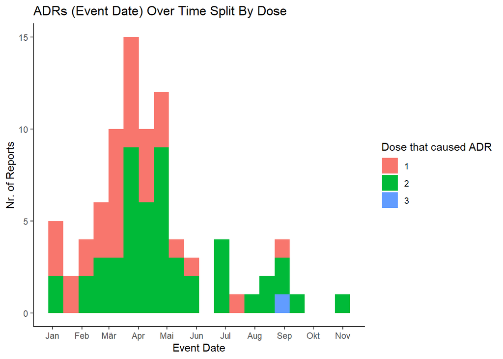

```r
pfi_comb <- rbind(pfi_m, pfi_d)
# x = Event Date
pfi_comb %>% filter(cause == 1) %>% ggplot(aes(x = as.Date(case_event_date), fill = as.factor(dose_nr))) +
    geom_histogram(bins = 20) +
    theme_classic() +
    xlab(label = "Event Date") +
    ylab(label = "Nr. of Reports") +
    guides(fill = guide_legend(title = "Dose that caused ADR")) +
    labs(title = "ADRs (Event Date) Over Time Split By Dose") +
    scale_x_date(breaks="month", date_labels = "%b")
```

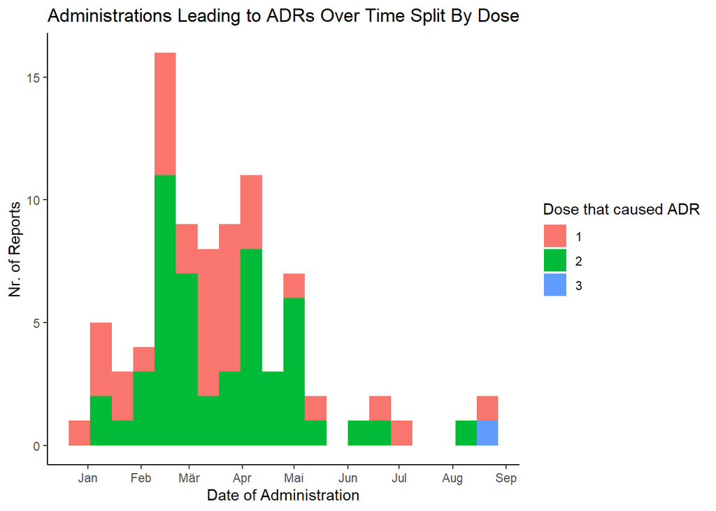

```r
# x = Date of administration
pfi_comb %>% filter(cause == 1) %>% ggplot(aes(x = as.Date(drugstartdate), fill = as.factor(dose_nr))) +
    geom_histogram(bins = 20) +
    theme_classic() +
    xlab(label = "Date of Administration") +
    ylab(label = "Nr. of Reports") +
    guides(fill = guide_legend(title = "Dose that caused ADR")) +
    labs(title = "Administrations Leading to ADRs Over Time Split By Dose") +
    scale_x_date(breaks="month", date_labels = "%b")
```

The distributions over time are not the same for the two plots. This implies that the time from the administration until the event is not always the same.

Plot the time from the administration to the event for all doses that where labelled to be likely the cause for the event and for which we have the exact days of the event:

```r
library(ggstance)
```

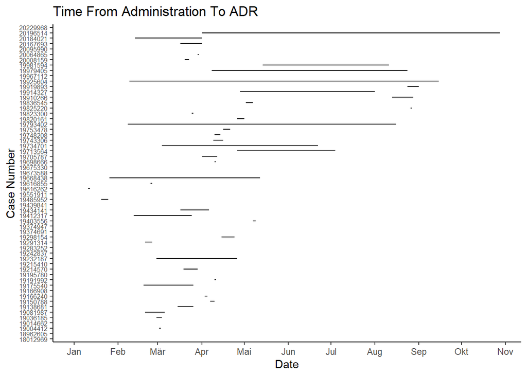

```r
pfi_comb %>% filter(precision_case_event_date == "day" & cause == 1) %>%
    ggplot(aes(y = as.factor(safetyreportid), xmin = as.Date(drugstartdate), xmax = as.Date(case_event_date))) +
    geom_linerangeh() +
    scale_x_date(breaks="month", date_labels = "%b") +
    theme_classic() +
    theme(axis.text.y = element_text(size = 6)) +
    xlab(label = "Date") +
    ylab(label = "Case Number") +
    labs(title = "Time From Administration To ADR")
```

We see that for some cases the time between administration and event is very long. Look at one of these records:

```r
pfi_comb %>% filter(safetyreportid == 20196514) %>% kable()
```

| safetyreportid | safetyreportversion | drugstartdate | case_event_date | precision_case_event_date | id_ver | dose_nr | cause |
| --- | --- | --- | --- | --- | --- | --- | --- |
| 20196514 | 1 | 2021-03-01 | 2021-10-28 | day | 20196514_1 | 1 | 0 |
| 20196514 | 1 | 2021-04-01 | 2021-10-28 | day | 20196514_1 | 2 | 1 |

Records like these should have been excluded, as here we really cant say which dose caused the ADR.  
Exclude cases where the event happened more then 30 days (= 2592000 s) after the dose (this cut off is more or less arbitrary)

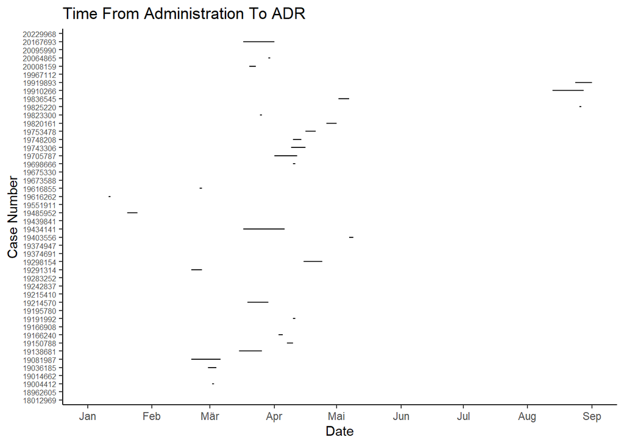

```r
drop <- pfi_comb %>% filter(cause == 1) %>% mutate(., t_adm_event = case_event_date - drugstartdate) %>%
    filter(t_adm_event > 2592000) %>% select(safetyreportid) %>% deframe()
#drop these cases
pfi_comb <- pfi_comb %>% filter(!(safetyreportid %in% drop))

#plot again
pfi_comb %>% filter(precision_case_event_date == "day" & cause == 1) %>%
    ggplot(aes(y = as.factor(safetyreportid), xmin = as.Date(drugstartdate), xmax = as.Date(case_event_date))) +
    geom_linerangeh() +
    scale_x_date(breaks="month", date_labels = "%b") +
    theme_classic() +
    theme(axis.text.y = element_text(size = 6)) +
    xlab(label = "Date") +
    ylab(label = "Case Number") +
    labs(title = "Time From Administration To ADR")
```

Repeat the two plots above:

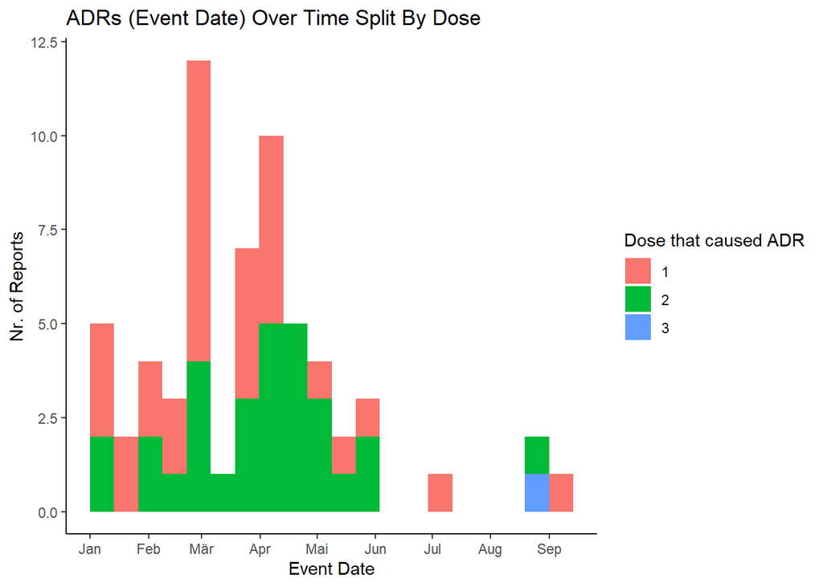

```r
# x = Event Date
pfi_comb %>% filter(cause == 1) %>% ggplot(aes(x = as.Date(case_event_date), fill = as.factor(dose_nr))) +
    geom_histogram(bins = 20) +
    theme_classic() +
    xlab(label = "Event Date") +
    ylab(label = "Nr. of Reports") +
    guides(fill = guide_legend(title = "Dose that caused ADR")) +
    labs(title = "ADRs (Event Date) Over Time Split By Dose") +
    scale_x_date(breaks="month", date_labels = "%b")
```

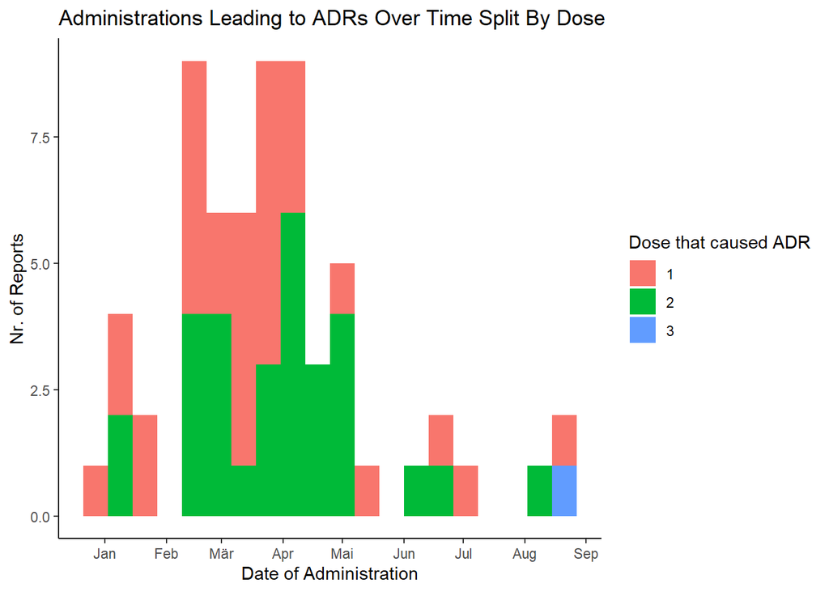

```r
# x = Date of administration
pfi_comb %>% filter(cause == 1) %>% ggplot(aes(x = as.Date(drugstartdate), fill = as.factor(dose_nr))) +
    geom_histogram(bins = 20) +
    theme_classic() +
    xlab(label = "Date of Administration") +
    ylab(label = "Nr. of Reports") +
    guides(fill = guide_legend(title = "Dose that caused ADR")) +
    labs(title = "Administrations Leading to ADRs Over Time Split By Dose") +
    scale_x_date(breaks="month", date_labels = "%b")
```

They look more similar now.

What are the total number of reports per dose?

```r
pfi_comb %>% group_by(dose_nr) %>% summarise(Nr_cases = sum(cause)) %>% kable()
```

| dose_nr | Nr_cases |
| --- | --- |
| 1 | 31 |
| 2 | 30 |
| 3 | 1 |

When we assume that the difference between the number of administrations per dose is negligible (meaning that not many people only got the first dose until the end of 2021) it seems that there is no real difference between the amount of reports between the first and second dose.

For the third dose I would not draw any conclusions from this data, as it only started to be administered at the end of 2021.

Lets have a look at how many doses of pfizer where administered compared to how many “series” where completed with pfizer (meaning the person got 2 vaccinations). On Sept. 20 administration of the booster started. Therefore we will look at the data one day before, since later the booster is also counted into the sum of administered doses.

```r
covac_us_tot %>% filter(Date == "2021-09-19") %>% select(Administered_Pfizer, Series_Complete_Pfizer) %>% kable()
```

| Administered_Pfizer | Series_Complete_Pfizer |
| --- | --- |
| 220600691 | 99042327 |

## 4.4 Linear Regression

We will now try to find some factors that show a correlation with the number of reported ADRs per dose administered (We will call this just “case per dose” for short)

We will again work with the data for the Pfizer vaccine.

The first question to ask is what we should choose to calculate the dependent variable (the receive date or the event date?). We will take the event date because I assume that it is decided around the time of the event, if the event will be reported or not / That the variables that influence if the event is reported have the biggest influence around the time the event happens.  
This means that this measure is more suited to represent the cases where the event took place shortly after the administration. This is not always the case. Therefore some error is introduced here.

We will bin the data by weeks, as otherwise we will have many values of zero for case per dose.

### 4.4.1 Setting up Dataframe

We will take the data used above (to explore if the dose number has an influence on reporting frequency) to calculate our dependent variable:

```r
pfi_admdates_dose_i %>% head() %>% kable
```

| safetyreportid | safetyreportversion | drugstartdate | case_event_date | precision_case_event_date | id_ver |
| --- | --- | --- | --- | --- | --- |
| 18671181 | 3 | 2020-12-17 | 2020-12-01 | month | 18671181_3 |
| 18766078 | 1 | 2020-12-29 | 2021-01-01 | month | 18766078_1 |
| 18702075 | 1 | 2020-12-28 | 2020-12-01 | month | 18702075_1 |
| 18735543 | 1 | 2021-01-04 | 2021-01-01 | month | 18735543_1 |
| 18724876 | 2 | 2020-12-31 | 2020-12-01 | month | 18724876_2 |
| 19065029 | 2 | 2021-03-04 | 2020-08-01 | month | 19065029_2 |

We only need the newest versions of the cases and the event date. We will add the version number to the report id, then group by the report id and select for the highest value of report id + version. Like this we can select the records from the newest version. We will also remove cases with impossible values.

```r
#add id for report + version
pfi_event_dates_1 <- pfi_admdates_dose_i %>% mutate(id_ver = safetyreportid + safetyreportversion)
#select the newest versions and drop the columns that are not needed
pfi_event_dates_2 <- pfi_event_dates_1 %>% group_by(safetyreportid) %>% slice_max(n = 1, id_ver) %>% select(safetyreportid, drugstartdate, case_event_date, precision_case_event_date)

#for the records where we only know the month we will drop all the records, where
#the drugstartdate was more then 31 days after the event date (to get rid of cases with impossible values)
pfi_event_dates_3m <- pfi_event_dates_2 %>% filter(precision_case_event_date == "month") %>%
    filter(!(drugstartdate > (as.Date(case_event_date) + 31)))
#for the cases where the administration and the event where in the same month we will add the
#administration date as event date (as it is probably our best guess thereof)
pfi_event_dates_3m_1 <- pfi_event_dates_3m %>% mutate(., m_event = format(case_event_date, format = "%m")) %>%
    mutate(., m_dose = format(drugstartdate, format = "%m")) %>%
    mutate(., dif_e_d = as.numeric(m_event) - as.numeric(m_dose)) %>%
    filter(dif_e_d == 0) %>% mutate(case_event_date = drugstartdate) %>% .[,1:4]
#the rest we leave as is:
pfi_event_dates_3m_2 <- pfi_event_dates_3m %>% mutate(., m_event = format(case_event_date, format = "%m")) %>%
    mutate(., m_dose = format(drugstartdate, format = "%m")) %>%
    mutate(., dif_e_d = as.numeric(m_event) - as.numeric(m_dose)) %>%
    filter(dif_e_d != 0)
#reunite the two groups
pfi_event_dates_3m_u <- rbind(pfi_event_dates_3m_1, pfi_event_dates_3m_2)

#remove all records where the administration date was after the event date for
#the records where we know the exact date
pfi_event_dates_3d <- pfi_event_dates_2 %>% filter(precision_case_event_date == "day") %>% filter(!(drugstartdate > case_event_date))

#reunite all the records:
pfi_event_dates_4 <- rbind(pfi_event_dates_3d, pfi_event_dates_3m_u)

#drop the drugstartdate column and filter for unique columns (to filter out different doses from same case)
pfi_event_dates_5 <- pfi_event_dates_4 %>% select(safetyreportid, case_event_date) %>% unique()

#display results
pfi_event_dates_5 %>% arrange(safetyreportid) %>% head(n = 10) %>% kable()
```

| safetyreportid | case_event_date |
| --- | --- |
| 18012969 | 2021-03-25 |
| 18671098 | 2020-12-18 |
| 18671181 | 2020-12-17 |
| 18685443 | 2021-04-01 |
| 18696562 | 2020-12-17 |
| 18702075 | 2020-12-28 |
| 18724701 | 2020-12-31 |
| 18724876 | 2020-12-31 |
| 18730288 | 2020-12-18 |
| 18731951 | 2020-12-18 |

Now we will make bins of the values per week:

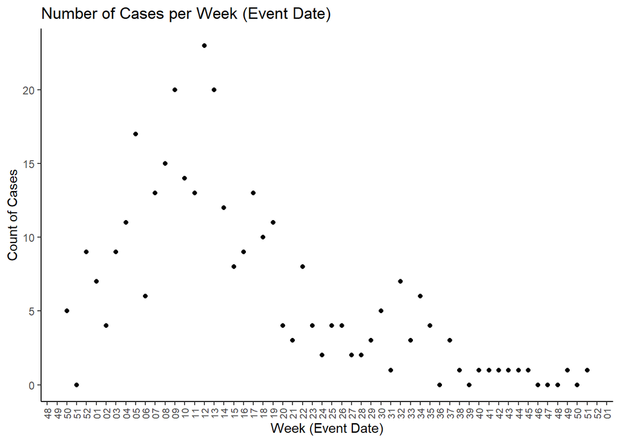

```r
pfi_event_dates_6 <- pfi_event_dates_5 %>% .[,"case_event_date"] %>% deframe() %>% cut(., breaks = "week") %>% table() %>% data.frame()
colnames(pfi_event_dates_6) <- c("Week", "count_cases")

#plot the result
pfi_event_dates_6 %>% ggplot(aes(x = as.Date(Week), y = count_cases)) +
    geom_point() +
    scale_x_date(breaks="week", date_labels = "%W") +
    theme_classic() +
    theme(axis.text.x = element_text(angle = 90, hjust = 0.5, vjust = 0.5, size = 8)) +
    xlab(label = "Week (Event Date)") +
    ylab(label = "Count of Cases") +
    labs(title = "Number of Cases per Week (Event Date)")
```

Now we will add information about doses administered per week (we had previously calculated this from the cumulated number of doses)

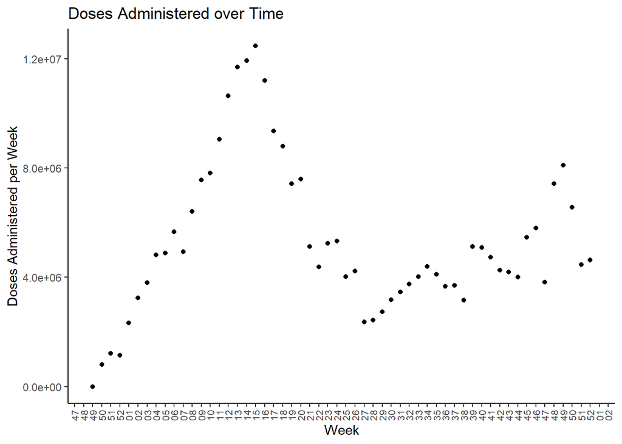

```r
#merge this with the data of administrations per week
pfi_event_dates_7 <- merge(x = pfi_adm_pw, y = pfi_event_dates_6, by = "Week", all.x = T)
#drop the records from 2022, as we dont have ADR data for those
pfi_event_dates_7 <- pfi_event_dates_7[as.Date(pfi_event_dates_7$Week) <= "2021-12-31",]
#replace the produced NAs in the count_cases column with 0 (we have ADR data from these
#week and know that there where no events,that started then)
pfi_event_dates_7[is.na(pfi_event_dates_7$count_cases) == TRUE, "count_cases"] <- 0

#plot
pfi_event_dates_7 %>% ggplot(aes(x = as.Date(Week), y = nr_adm_pw)) +
    geom_point() +
    scale_x_date(breaks="week", date_labels = "%W") +
    theme_classic() +
    theme(axis.text.x = element_text(angle = 90, hjust = 0.5, vjust = 0.5, size = 8)) +
    xlab(label = "Week") +
    ylab(label = "Doses Administered per Week") +
    labs(title = "Doses Administered over Time")
```

Calculate the reported events that happened per administered dose for each week. We will leave in count_cases, nr_adm_pw to check later if any of the independent variables show a correlation with one of these.

```r
pfi_event_dates_8 <- pfi_event_dates_7 %>% mutate(case_per_dose = count_cases/nr_adm_pw) %>%
    select(Week, case_per_dose, count_cases, nr_adm_pw)
```

Now we will convert the weeks column from factor to date and produce a plot:

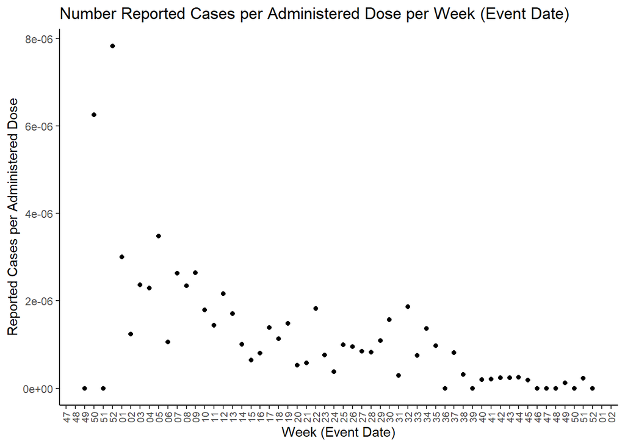

```r
pfi_event_dates_9 <- pfi_event_dates_8 %>% select(Week) %>% lapply(., as.Date) %>% cbind(Week = ., pfi_event_dates_8[,2:4])

#plot
pfi_event_dates_9 %>% ggplot(aes(x = Week, y = case_per_dose)) +
    geom_point() +
    scale_x_date(breaks="week", date_labels = "%W") +
    theme_classic() +
    theme(axis.text.x = element_text(angle = 90, hjust = 0.5, vjust = 0.5, size = 8)) +
    xlab(label = "Week (Event Date)") +
    ylab(label = "Reported Cases per Administered Dose") +
    labs(title = "Number Reported Cases per Administered Dose per Week (Event Date)")
```

There seems to be a more or less linear relationship between time and reported cases per administered dose during the year 2021. Before (during the first few weeks of the vaccine campaign) the data shows huge variability (2 weeks with no cases reported, 2 weeks with the highest values of the whole dataset).  
The reason for this are probably the low number of administered doses, which means, that a small difference in reported cases has a big impact on our measure.  
It is also important to note that the variance seems to decrease with time (the data is heteroscedastic).  
It is also possible that an exponential decay would better describe the data then a linear model. The argument being that reported cases per week will likely not reach 0 somewhere in 2022 (and after that negative values).

Now we will add some independent variables.

Lets add series completed with pfizer per week (= second dose received):

```r
#calculate the number of series completed per day from the cumulated data
series_compl_pd <- covac_us_tot %>% select(Series_Complete_Pfizer) %>% sapply(., function(x){abs(diff(x))}) %>% rbind(NA, .) %>%
    cbind(covac_us_tot[,c("Date", "Series_Complete_Pfizer")], adm_pfi_pd_2nd = .[,]) %>% .[,c(2,4)]
#bin th edata per week
series_compl_pw <- series_compl_pd %>% mutate(Week = cut.Date(Date, breaks = "week")) %>%
    group_by(Week) %>%
    summarise(series_compl_pw = sum(adm_pfi_pd_2nd), .groups = "drop")
#transform Week to date
series_compl_pw <- series_compl_pw %>% select(Week) %>%
    lapply(., as.Date) %>%
    cbind(Week = ., series_compl_pw[,2])
#add to our dataframe
pfi_event_dates_9 <- merge(x = pfi_event_dates_9, y = series_compl_pw, by = "Week", all.x = T)
```

We can now calculate the percentage of second doses administered from all doses administered, which could have an influence on case per dose:

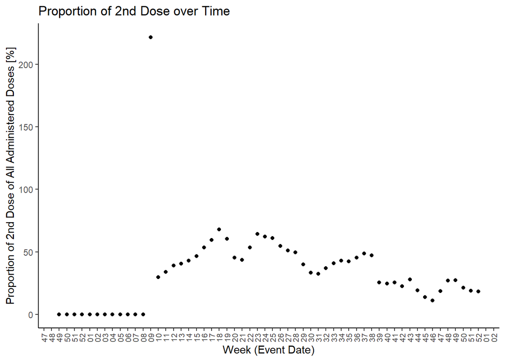

```r
pfi_event_dates_9 <- pfi_event_dates_9 %>% mutate(perc_2nd_dose = series_compl_pw/nr_adm_pw*100)
#plot over time
pfi_event_dates_9 %>% ggplot(aes(x = Week, y = perc_2nd_dose)) +
    geom_point() +
    scale_x_date(breaks="week", date_labels = "%W") +
    theme_classic() +
    theme(axis.text.x = element_text(angle = 90, hjust = 0.5, vjust = 0.5, size = 8)) +
    xlab(label = "Week (Event Date)") +
    ylab(label = "Proportion of 2nd Dose of All Administered Doses [%]") +
    labs(title = "Proportion of 2nd Dose over Time")
```

We see that there is one impossible value of >200% in week 09. This is probably due to an inconsistency in the data. There is one day in this week (2021-03-04) where apparently 15’614’063 series where completed with Pfizer (compared to a few 100’000s the days before and after). The number of doses administered on this day was 1’180’432. So this value is clearly impossible. I assume that this number was initially not captured by the government and this high value served to “bring the data up to speed” / to get the accurate number of people, who where vaccinated twice afterwards even if the exact day of these vaccinations was unknown. This would also explain, why we have values of 0 before this week, which does not seem plausible, since vaccinations started in Dec 2020 and the second dose should be administered around 1 month after the first.  
It is also important to note that on 2021-09-20 administration of “the booster” / the 3rd dose was started in the US. This means the third dose is also part of the total administered doses after that.  
We see quite an abrupt drop in the value after this week. This is probably because the numbers of administrations of the first and second dose did not change drastically, but there was a strong increase in the third dose (starting from 0).

Now we will add as well some data about covid cases and covid deaths per week. One could speculate, that in times where there where more cases or deaths, there was more media attention on covid and maybe also the vaccine, which could have led to more cases beeing reported.

Load in dataset (https://data.cdc.gov/Case-Surveillance/United-States-COVID-19-Cases-and-Deaths-by-State-o/9mfq-cb36, accessed on 14.04.2022)

```r
covid_cases_us <- read.csv(file = "United_States_COVID-19_Cases_and_Deaths_by_State_over_Time.csv")
covid_cases_us %>% head() %>% kable()
```

| submission_date | state | tot_cases | conf_cases | prob_cases | new_case | pnew_case | tot_death | conf_death | prob_death | new_death | pnew_death | created_at | consent_cases | consent_deaths |
| --- | --- | --- | --- | --- | --- | --- | --- | --- | --- | --- | --- | --- | --- | --- |
| 01/14/2022 | KS | 621273 | 470516 | 150757 | 19414 | 6964 | 7162 | NA | NA | 21 | 4 | 01/15/2022 02:59:30 PM | Agree | N/A |
| 10/20/2020 | CO | 90910 | 83758 | 7152 | 1116 | 90 | 2182 | 1801 | 381 | 2 | 1 | 10/20/2020 12:00:00 AM | Agree | Agree |
| 02/04/2020 | AR | 0 | NA | NA | 0 | NA | 0 | NA | NA | 0 | NA | 03/26/2020 04:22:39 PM | Not agree | Not agree |
| 12/06/2021 | MP | 1104 | 1104 | 0 | 0 | 0 | 5 | 5 | 0 | 2 | 0 | 12/08/2021 12:00:00 AM | Agree | Agree |
| 05/09/2021 | PW | 0 | NA | NA | 0 | 0 | 0 | NA | NA | 0 | 0 | 05/10/2021 02:15:36 PM |  |  |
| 01/01/2022 | UT | 636992 | 636992 | 0 | 0 | 0 | 3787 | 3635 | 152 | 0 | 0 | 01/03/2022 01:55:55 PM | Agree | Agree |

We get data per date and per state. We will use the data from columns “new_case”, and “new_death” and cummulate them per date to get the total value for the US.

```r
covid_cases_us_aggr_1 <- covid_cases_us %>% select(submission_date, new_case, new_death) %>%
    group_by(submission_date) %>%
    summarise(new_case_US = sum(new_case), new_death_US = sum(new_death), .groups = "drop")
```

Now we will bin the numbers by weeks:

```r
#what is the format of submission_date?
#covid_cases_us_aggr_1 %>% select(submission_date) %>% unique()
# its %m/%d/%Y

#transform submission_date to date:
covid_cases_us_aggr_2 <- covid_cases_us_aggr_1 %>% select(submission_date) %>%
    lapply(., as.Date, format = "%m/%d/%Y") %>%
    cbind(submission_date = ., covid_cases_us_aggr_1[, 2:3])
#bin per week
covid_cases_us_pw <- covid_cases_us_aggr_2 %>% mutate(Week = cut.Date(submission_date, breaks = "week")) %>%
    group_by(Week) %>%
    summarise(new_case_US_pw = sum(new_case_US), new_death_US_pw = sum(new_death_US), .groups = "drop")
#transform Week to date
covid_cases_us_pw <- covid_cases_us_pw %>% select(Week) %>%
    lapply(., as.Date) %>%
    cbind(Week = ., covid_cases_us_pw[,2:3])
#display
covid_cases_us_pw %>% head(n = 10) %>% kable()
```

| Week | new_case_US_pw | new_death_US_pw |
| --- | --- | --- |
| 2020-01-20 | 3 | 0 |
| 2020-01-27 | 5 | 0 |
| 2020-02-03 | 4 | 0 |
| 2020-02-10 | 2 | 0 |
| 2020-02-17 | 22 | 0 |
| 2020-02-24 | 52 | 2 |
| 2020-03-02 | 725 | 28 |
| 2020-03-09 | 6497 | 74 |
| 2020-03-16 | 44085 | 508 |
| 2020-03-23 | 122030 | 2726 |

Merge this data with our dataframe:

```r
pfi_event_dates_10 <- merge(x = pfi_event_dates_9, y = covid_cases_us_pw, by = "Week", all.x = T)
```

### 4.4.2 Matrix Plots of all Variables

In order to assess which of the independent variables might show a linear relationship with the dependent variable, and if there are any correlations between some of the independent variables, we will produce a matrix of scatter plots for all the variables.

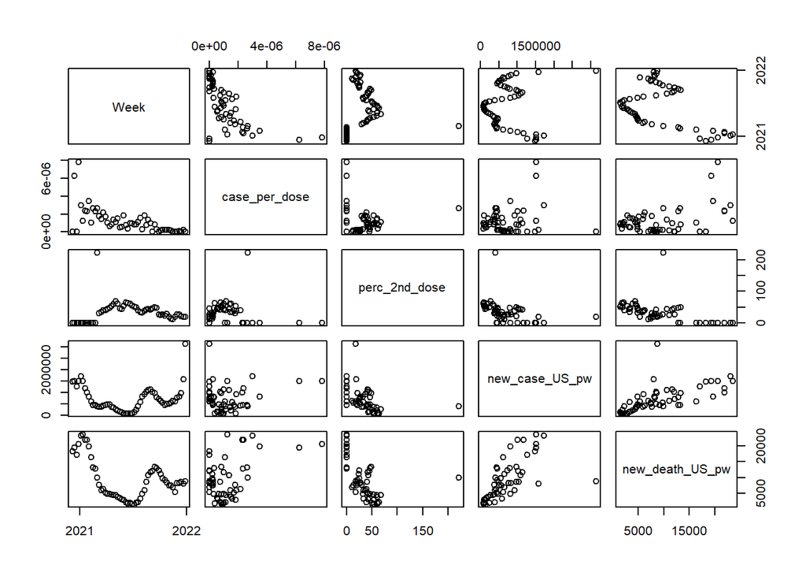

```r
#plot dependent and independent variables
pairs(pfi_event_dates_10[,c(1, 2, 6, 7, 8)])
```

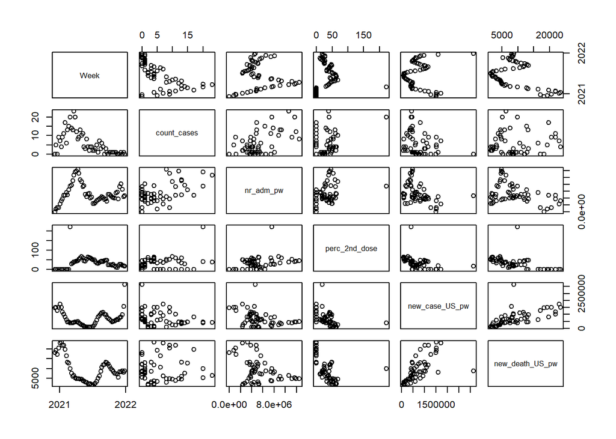

```r
#plot independent variables and variables from which independent variable was derived
pairs(pfi_event_dates_10[,c(1, 3, 4, 6, 7, 8)])
```

Discuss the independent variables and their relationships:

- Week:  
  The relationship with cases_per_dose was discussed above. It seems not to have a linear relationship with any of the other independent variables (which we would also not suspect intuitively.)
- Percentage of 2nd dose:  
  As discussed before there seems to be one data point which is wrong. We will redo the plot above but only for the time period after this data point (which removes all the 0 values before this, which are probably also incorrect.)

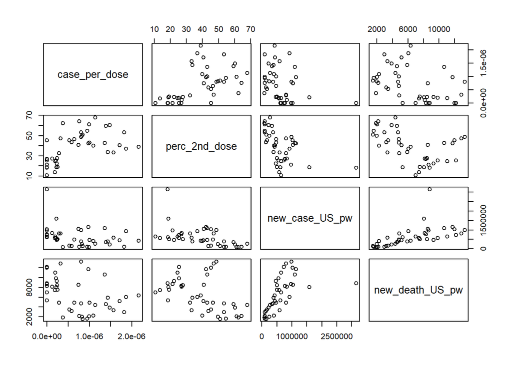

```r
pairs(pfi_event_dates_10[15:56,c(2, 6, 7, 8)])
```

It looks like there is no strong linear correlations between Percentage of 2nd dose and number of case reports per administered dose. There might be a negative correlations between Percentage of 2nd dose and new cases (There is one outlier => very high number of new cases for one week). With the number of deaths there seems not to be a correlation either.  
Because after September 20 2021 also the 3rd dose was administered, I will now repeat the plot with the data before this. Since in this period Percentage of 2nd dose represents the number of 2nd doses administered vs first doses administered (afterwards it is number of 2nd doses administered vs first and 3rd doses administered).

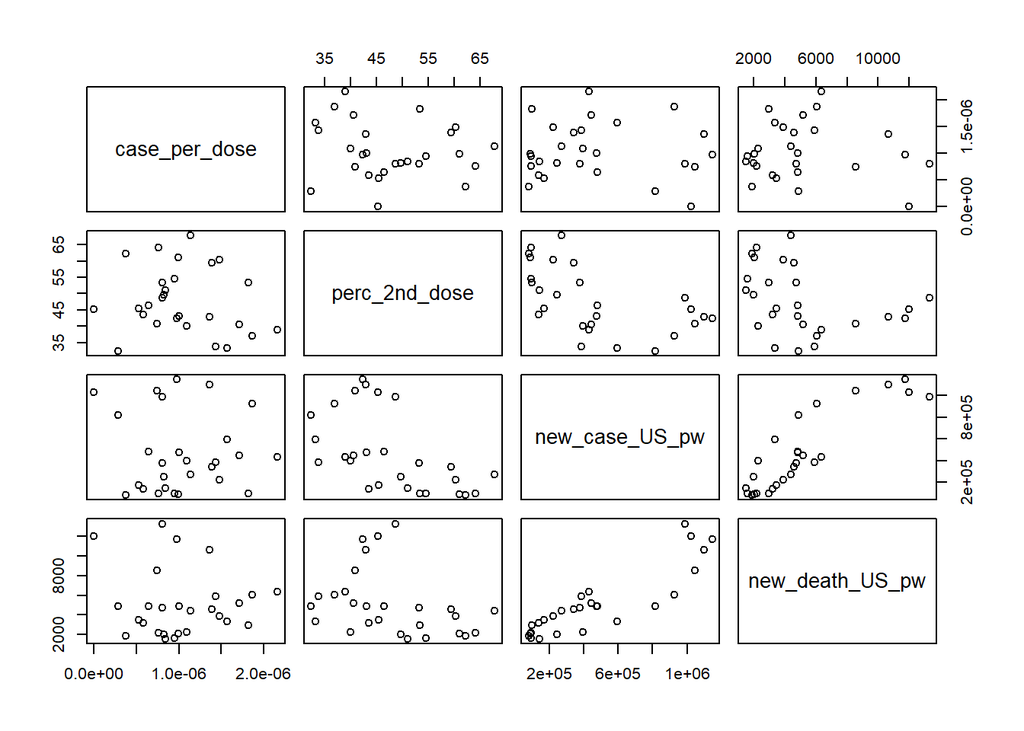

```r
pairs(pfi_event_dates_10[15:41,c(2, 6, 7, 8)])
```

In this plot it is even more clear that there is no correlation between Percentage of 2nd doses administered and number of reported cases per administered dose.

- New Cases / New Deaths:  
  There does not seem to be a correlation between number of reported cases per dose with New Cases nor New Deaths.  
  There seems to be a correlation between New Cases and New Deaths, which is no surprise.

The function GGally::ggpairs creates a scatterplot matrix including the correlation coefficient:

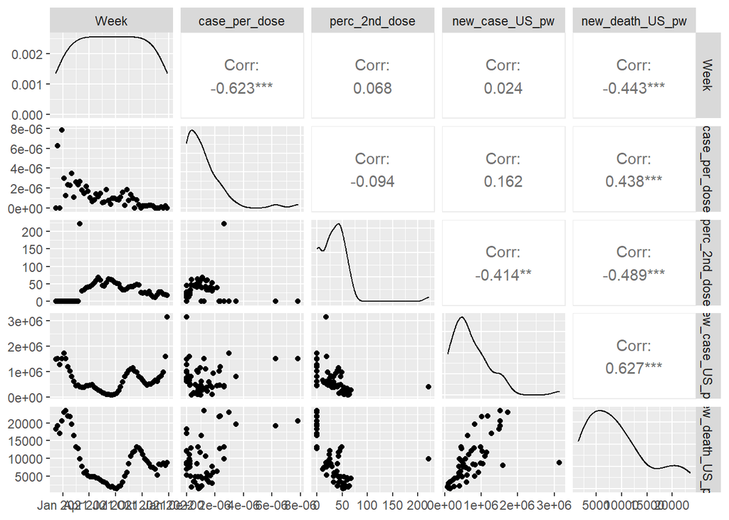

```r
library(GGally)
ggpairs(pfi_event_dates_10[,c(1, 2, 6, 7, 8)])
```

We can see here that correlation coefficient actually shows a significant correlation between new death and all of the other variables.  
There is also a significant correlation between Percentage 2nd dose and new cases, which might just be coincidence.  
The plots dont really show these correlations very clearly.

### 4.4.3 Multiple Regression

Looking at the scatter plots between the different variables gave us quite a good idea on which variables we should include in our model and what the relationship to the dependent variable might be. An exponential model with only the time as independent variable will probably make most sense. Instead of just fitting this model right away we will try out some other combinations in order to gain some intuition about linear regression.

#### 4.4.3.1 Model 1: Multiple Regression including all variables

Fit a multiple linear regression model including all independent variables and show model summary:

```r
lm1 <- pfi_event_dates_10 %>% lm(case_per_dose ~ Week + perc_2nd_dose + new_case_US_pw + new_death_US_pw, data = .)
summary(lm1)
```

```
##
## Call:
## lm(formula = case_per_dose ~ Week + perc_2nd_dose + new_case_US_pw +
##     new_death_US_pw, data = .)
##
## Residuals:
##        Min         1Q     Median         3Q        Max
## -3.009e-06 -4.079e-07  2.710e-08  1.903e-07  4.880e-06
##
## Coefficients:
##                   Estimate Std. Error t value Pr(>|t|)
## (Intercept)      1.340e-04  3.150e-05   4.255 8.95e-05 ***
## Week            -7.100e-09  1.669e-09  -4.255 8.94e-05 ***
## perc_2nd_dose    2.711e-09  5.425e-09   0.500    0.619
## new_case_US_pw   2.796e-13  3.988e-13   0.701    0.487
## new_death_US_pw  3.555e-11  4.180e-11   0.851    0.399
## ---
## Signif. codes:  0 '***' 0.001 '**' 0.01 '*' 0.05 '.' 0.1 ' ' 1
##
## Residual standard error: 1.131e-06 on 51 degrees of freedom
## Multiple R-squared:  0.4287, Adjusted R-squared:  0.3839
## F-statistic: 9.569 on 4 and 51 DF,  p-value: 7.519e-06
```

As could have been expected from looking at the scatter plots above, “Week” shows a significant correlation with the dependent variable, while the other independent variables, clearly do not.  
Overall the model is not very good (showing an adjusted R-squared value of 0.3839).  
However the F-statistic confirms that there is at least one independent variable, that correlates significantly with our dependent variable. This was to be expected, since the p-value for “week” would be quite unlikely to take on this value just by chance.

Produce a plot for each independent variable against the dependent variable including the model fit:

- Week vs. case per dose

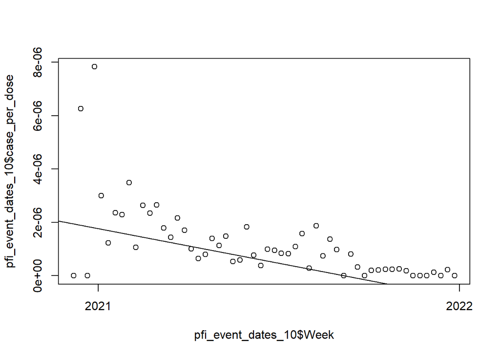

```r
#create the scatter plot
plot(pfi_event_dates_10$Week, pfi_event_dates_10$case_per_dose)
#add fitted regression line
abline(a = lm1$coefficients[[1]], b = lm1$coefficients[[2]])
```

Here we can clearly see one of the defects of this model: It predicts values below 0 for cases per dose after a certain point in time. I assume that if we would fit a linear model including only Week as independent variable, the model would cross y = 0 at a “later point in time” meaning the fit would produce plausible values for a longer time period. However the fundamental problem of using a linear model would persist.

For the other independent variables in the model, the fit is off by a lot (the y intersect is 1.34e-04), therefore the fitted line does not appear on the plots, if we produce them like we did above for Week:

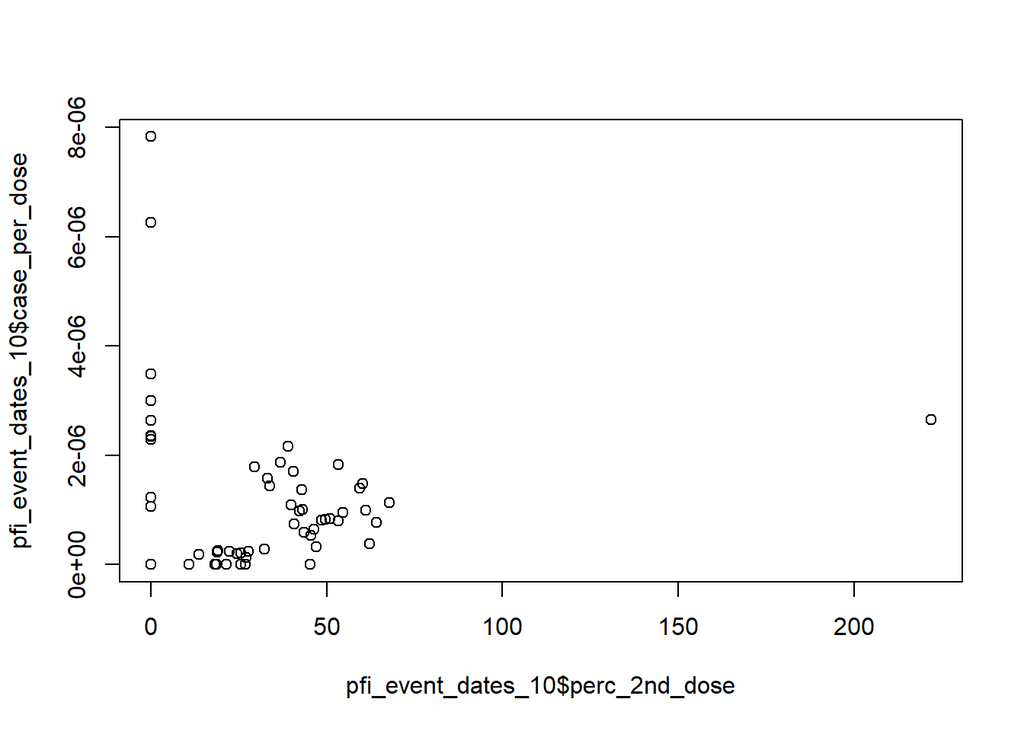

```r
#create the scatter plot
plot(pfi_event_dates_10$perc_2nd_dose, pfi_event_dates_10$case_per_dose)
#add fitted regression line
abline(a = lm1$coefficients[[1]], b = lm1$coefficients[[3]])
```

This means the fitted model does not really reflect their relationship with the dependent variable very well.

This observation also made me look more closely at how the Week variable is fit by the model. The peculiarity being that it is a date. This means that the value of 0 for date is a certain date that is defined as the origin.  
Find out what is approximately the origin used in our data:

```r
pfi_event_dates_10[1, "Week"] %>% as.numeric()
```

```
## [1] 18603
```

```r
#2020-12-07 = 18603 (I assume this is the number of days since the origin)
18603/365
```

```
## [1] 50.96712
```

The origin is around 51 years before the end of 2021 => in 1970  
(1st of January 1970 is often used as origin date.) The y-intercept represents the extrapolated y-value of our model fit at the origin.

Via an internet search I found the recommendation to shift the origin to a date close or within the time period of the observation in such a case. We will do this below.

**Check the Assumptions of the Model**

- Normality of Residuals:

Plot a histogram of the residuals:

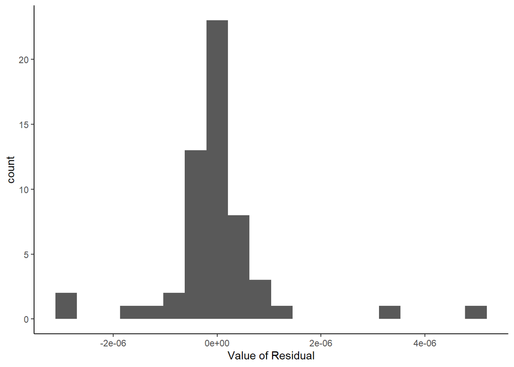

```r
residuals(lm1) %>% data.frame() %>% ggplot(aes(x = .)) +
    geom_histogram(bins = 20) +
    xlab(label = "Value of Residual") +
    theme_classic()
```

There are exceptionally high / low values for some residuals. The main part of the histogram (around 0) does not look very symmetrical.

- Consistent Variance over the range of the observations:

Produce a scatter plot for the fitted values vs the residuals

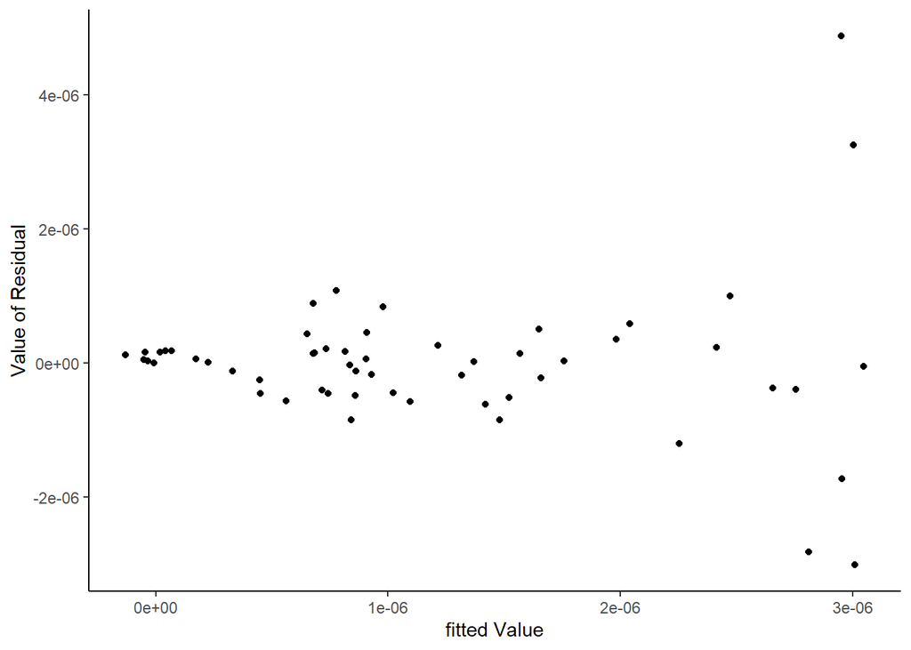

```r
lm1 %>% ggplot(aes(x = fitted(lm1), y = residuals(lm1))) +
    geom_point() +
    xlab(label = "fitted Value") +
    ylab(label = "Value of Residual") +
    theme_classic()
```

The variance clearly increases for higher fitted values. This clearly does not fullfill the model assumptions.

We had previously already established, that there were also correlations between some of the independent variables, which also violates the model assumptions.

This model therefore might not show accurate results.

We will now take several actions to try and improve the model.

#### 4.4.3.2 Model 2: Shift origin of time variable

We will fit the model again, with a shifted origin for the dates of the Week variable. The simplest way to do so is to just replace the dates with numbers starting at 0:

```r
pfi_event_dates_11 <- cbind(Week = c(0:55), pfi_event_dates_10[, 2:8])
```

Repeat the model fit with this data:

```r
lm2 <- pfi_event_dates_11 %>% lm(case_per_dose ~ Week + perc_2nd_dose + new_case_US_pw + new_death_US_pw, data = .)
summary(lm2)
```

```
##
## Call:
## lm(formula = case_per_dose ~ Week + perc_2nd_dose + new_case_US_pw +
##     new_death_US_pw, data = .)
##
## Residuals:
##        Min         1Q     Median         3Q        Max
## -3.009e-06 -4.079e-07  2.710e-08  1.903e-07  4.880e-06
##
## Coefficients:
##                   Estimate Std. Error t value Pr(>|t|)
## (Intercept)      1.943e-06  6.269e-07   3.099  0.00315 **
## Week            -4.970e-08  1.168e-08  -4.255 8.94e-05 ***
## perc_2nd_dose    2.711e-09  5.425e-09   0.500  0.61948
## new_case_US_pw   2.796e-13  3.988e-13   0.701  0.48651
## new_death_US_pw  3.555e-11  4.180e-11   0.851  0.39900
## ---
## Signif. codes:  0 '***' 0.001 '**' 0.01 '*' 0.05 '.' 0.1 ' ' 1
##
## Residual standard error: 1.131e-06 on 51 degrees of freedom
## Multiple R-squared:  0.4287, Adjusted R-squared:  0.3839
## F-statistic: 9.569 on 4 and 51 DF,  p-value: 7.519e-06
```

We see that the adjusted R-squared nor the F statistic did change much. However now the y intercept can be interpreted more easily (the modeled value of cases per administration at the beginning of the concerned time period).

Lets look again at the scatter plots including the model fit:

- Week:

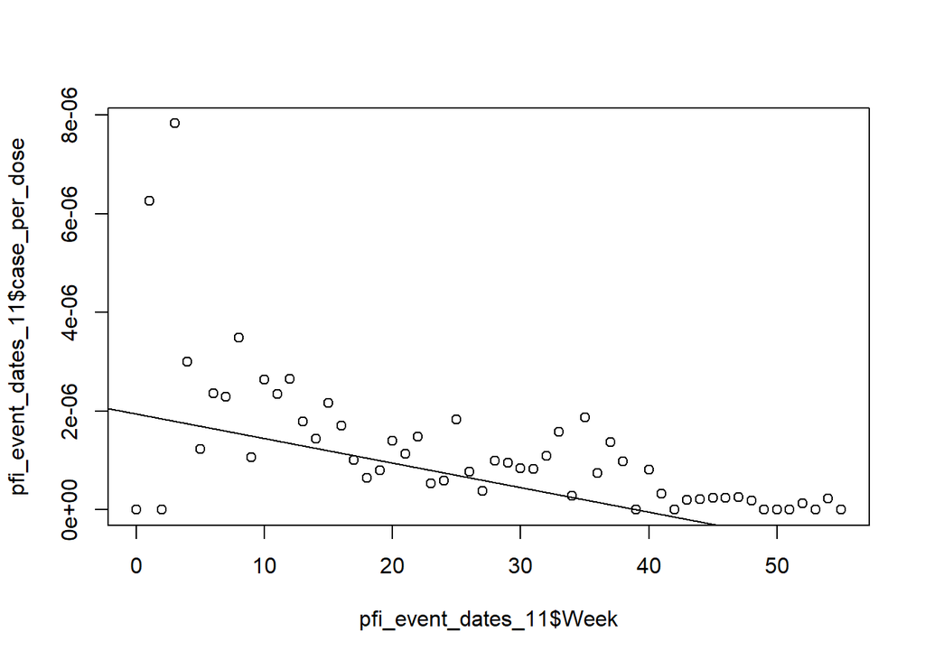

```r
#create the scatter plot
plot(pfi_event_dates_11$Week, pfi_event_dates_11$case_per_dose)
#add fitted regression line
abline(a = lm2$coefficients[[1]], b = lm2$coefficients[[2]])
```

Not much changed compared to the fit of the first model.

- Percentage of 2nd dose

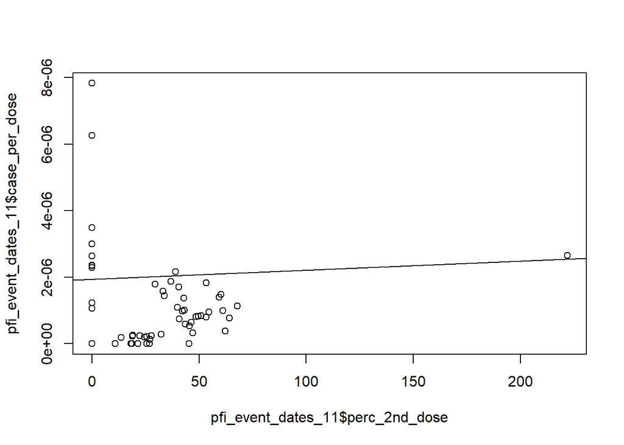

```r
#create the scatter plot
plot(pfi_event_dates_11$perc_2nd_dose, pfi_event_dates_11$case_per_dose)
#add fitted regression line
abline(a = lm2$coefficients[[1]], b = lm2$coefficients[[3]])
```

Now we got a model, that is more close to the actual data.

#### 4.4.3.3 Removing outliers

We will now try to identify outliers in the data and explore what the impact of excluding them on the model might be.  
We had already discussed peculiarities in our data (when looking at relationsips between two variables). This gives us an idea of which data points might be outliers.

##### 4.4.3.3.1 Cooks Distance

In order to identify outliers based on several variables we can use the Cooks distance. It provides information about how much the fit was influenced by each record.

Calculate Cooks Distances for the last model and plot:

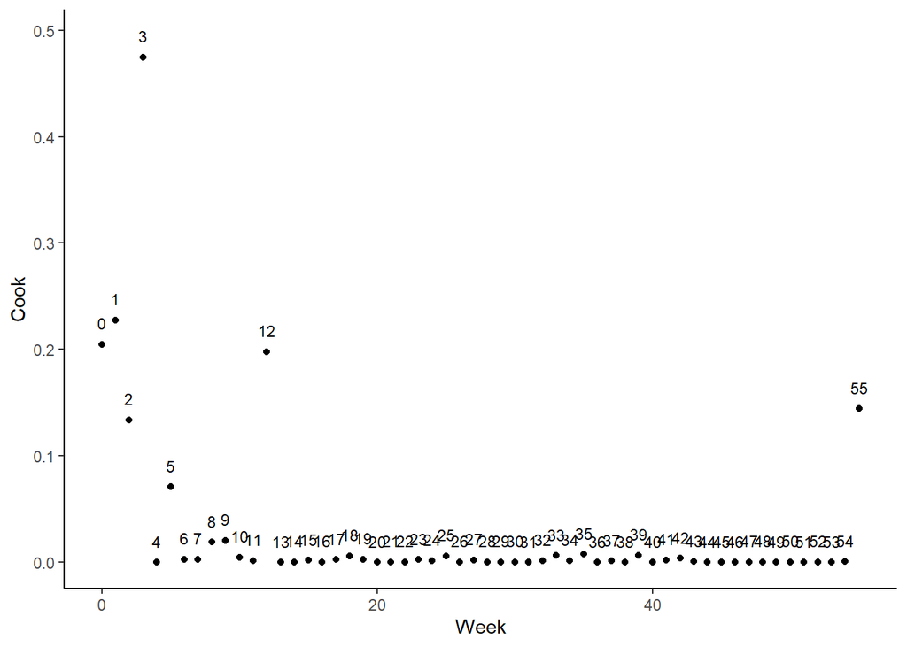

```r
cooks.distance(lm2) %>% cbind(pfi_event_dates_11, Cook = .) %>%
    ggplot(aes(x = Week, y = Cook)) +
    geom_point() +
    geom_text(aes(label = Week), size = 3, nudge_y = 0.02) +
    theme_classic()
```

By reducing the time period for the data included in the model from week 4 to week 54 We can exclude several points that show an extraordinarily high influence on the model.  
As tor the point labeled with 12 I assume this is the record with the impossibly high value for Percentage 2nd dose.

Lets look at the first four records:

```r
pfi_event_dates_11[c(1:4), c(1, 2, 6, 7, 8)] %>% kable()
```

| Week | case_per_dose | perc_2nd_dose | new_case_US_pw | new_death_US_pw |
| --- | --- | --- | --- | --- |
| 0 | 0.0e+00 | 0 | 1489390 | 18278 |
| 1 | 6.3e-06 | 0 | 1515973 | 19276 |
| 2 | 0.0e+00 | 0 | 1277348 | 17107 |
| 3 | 7.8e-06 | 0 | 1515335 | 20584 |

The first four records have a case per dose value of either 0 or the highest two values of the whole dataset (more or less twice as high as the next biggest), which might explain the high Cooks distance.

Look at the last records:

```r
pfi_event_dates_11[c(50:56), c(1, 2, 6, 7, 8)] %>% kable()
```

|  | Week | case_per_dose | perc_2nd_dose | new_case_US_pw | new_death_US_pw |
| --- | --- | --- | --- | --- | --- |
| 50 | 49 | 0e+00 | 10.88935 | 647686 | 6991 |
| 51 | 50 | 0e+00 | 18.66808 | 614739 | 5334 |
| 52 | 51 | 0e+00 | 26.87703 | 767564 | 8335 |
| 53 | 52 | 1e-07 | 27.19286 | 834446 | 8169 |
| 54 | 53 | 0e+00 | 21.39835 | 975145 | 8673 |
| 55 | 54 | 2e-07 | 18.83921 | 1589156 | 8086 |
| 56 | 55 | 0e+00 | 18.28823 | 3142360 | 8810 |

For the last record I am unsure of what the reason might be. It does not seem that much out of the ordinary compared to the weeks before.

Lets look at records around week number 12:

```r
pfi_event_dates_11[c(5:13), c(1, 2, 6, 7, 8)] %>% kable()
```

|  | Week | case_per_dose | perc_2nd_dose | new_case_US_pw | new_death_US_pw |
| --- | --- | --- | --- | --- | --- |
| 5 | 4 | 3.0e-06 | 0.0000 | 1723061 | 23100 |
| 6 | 5 | 1.2e-06 | 0.0000 | 1512425 | 23511 |
| 7 | 6 | 2.4e-06 | 0.0000 | 1179403 | 21900 |
| 8 | 7 | 2.3e-06 | 0.0000 | 1011947 | 21866 |
| 9 | 8 | 3.5e-06 | 0.0000 | 811237 | 19700 |
| 10 | 9 | 1.1e-06 | 0.0000 | 622190 | 16404 |
| 11 | 10 | 2.6e-06 | 0.0000 | 444101 | 13176 |
| 12 | 11 | 2.3e-06 | 0.0000 | 465458 | 12812 |
| 13 | 12 | 2.6e-06 | 221.8955 | 402777 | 9873 |

The high cook distance for the record of week nr. 12 was probably due to the high value of Percentage 2nd dose. We can try to correct it by just setting the value to the mean of its two neighboring values. We will do this in the fourth model in order to see the influence of the measures taken one by one.

#### 4.4.3.4 Model 3: Reduce time period to remove outliers

```r
lm3 <- pfi_event_dates_11[5:55,] %>% lm(case_per_dose ~ Week + perc_2nd_dose + new_case_US_pw + new_death_US_pw, data = .)
summary(lm3)
```

```
##
## Call:
## lm(formula = case_per_dose ~ Week + perc_2nd_dose + new_case_US_pw +
##     new_death_US_pw, data = .)
##
## Residuals:
##        Min         1Q     Median         3Q        Max
## -1.284e-06 -2.285e-07  2.730e-08  1.477e-07  1.352e-06
##
## Coefficients:
##                   Estimate Std. Error t value Pr(>|t|)
## (Intercept)      1.996e-06  3.000e-07   6.654 3.02e-08 ***
## Week            -4.639e-08  6.256e-09  -7.416 2.17e-09 ***
## perc_2nd_dose    2.603e-09  2.529e-09   1.029    0.309
## new_case_US_pw   2.809e-13  3.244e-13   0.866    0.391
## new_death_US_pw  1.400e-11  2.418e-11   0.579    0.565
## ---
## Signif. codes:  0 '***' 0.001 '**' 0.01 '*' 0.05 '.' 0.1 ' ' 1
##
## Residual standard error: 5.21e-07 on 46 degrees of freedom
## Multiple R-squared:  0.6793, Adjusted R-squared:  0.6515
## F-statistic: 24.36 on 4 and 46 DF,  p-value: 7.242e-11
```

The adjusted R squared increased (from 0.3839 to 0.6515) compared to the last model.

#### 4.4.3.5 Model 4: Correct outlier from perc_2nd_dose

Correct the outlier in Percentage 2nd dose, as discussed above.

```r
pfi_event_dates_12 <- pfi_event_dates_11
pfi_event_dates_12[13,6] <- (pfi_event_dates_12[12,6] + pfi_event_dates_12[14,6] / 2)
```

Fit the model again:

```r
lm4 <- pfi_event_dates_12[5:55,] %>% lm(case_per_dose ~ Week + perc_2nd_dose + new_case_US_pw + new_death_US_pw, data = .)
summary(lm4)
```

```
##
## Call:
## lm(formula = case_per_dose ~ Week + perc_2nd_dose + new_case_US_pw +
##     new_death_US_pw, data = .)
##
## Residuals:
##        Min         1Q     Median         3Q        Max
## -1.277e-06 -2.231e-07  3.560e-09  2.548e-07  1.283e-06
##
## Coefficients:
##                   Estimate Std. Error t value Pr(>|t|)
## (Intercept)      2.665e-06  4.165e-07   6.398 7.31e-08 ***
## Week            -4.918e-08  6.215e-09  -7.913 3.98e-10 ***
## perc_2nd_dose   -7.859e-09  5.683e-09  -1.383    0.173
## new_case_US_pw   3.289e-13  3.240e-13   1.015    0.315
## new_death_US_pw -1.723e-11  2.903e-11  -0.593    0.556
## ---
## Signif. codes:  0 '***' 0.001 '**' 0.01 '*' 0.05 '.' 0.1 ' ' 1
##
## Residual standard error: 5.164e-07 on 46 degrees of freedom
## Multiple R-squared:  0.685,  Adjusted R-squared:  0.6577
## F-statistic: 25.01 on 4 and 46 DF,  p-value: 4.829e-11
```

The R squared value of the model did not change much, but the P-value of Percentage 2nd dose decreased.

I assume the reason for this might be, that Percentage 2nd dose does not reall help much in improving the fit of the model, therefore removing an outlier from it, does not improve the model much.  
However, when we removed outliers from the dependent variable in the third model this helped improve the fit of the model.

### 4.4.4 Choosing Model via Best Subset Method

We will now use the best subset method to find the best combination of variables to fit our Model. We will again exclude the outliers.

We will use the leaps::regsubsets function to do this:

```r
library(leaps)
#set up dataframe (excluding outliers)
pfi_event_dates_13 <- pfi_event_dates_12[5:55, c(1, 2, 6, 7, 8)]
#run best subsets analysis and display results
subsets <- regsubsets(case_per_dose ~ ., data = pfi_event_dates_13 , nvmax = 4)
sum.subsets <- summary(subsets)
sum.subsets
```

```
## Subset selection object
## Call: regsubsets.formula(case_per_dose ~ ., data = pfi_event_dates_13,
##     nvmax = 4)
## 4 Variables  (and intercept)
##                 Forced in Forced out
## Week                FALSE      FALSE
## perc_2nd_dose       FALSE      FALSE
## new_case_US_pw      FALSE      FALSE
## new_death_US_pw     FALSE      FALSE
## 1 subsets of each size up to 4
## Selection Algorithm: exhaustive
##          Week perc_2nd_dose new_case_US_pw new_death_US_pw
## 1  ( 1 ) "*"  " "           " "            " "
## 2  ( 1 ) "*"  "*"           " "            " "
## 3  ( 1 ) "*"  "*"           "*"            " "
## 4  ( 1 ) "*"  "*"           "*"            "*"
```

The output above shows us which variables where included in the best model per model size (how many variables are included). We see, that Week gave the best prediction out of the models that utilize only one variable. This is what we would expect due to the scatterplots and the previously fitted models.

Lets look at some of the metrics provided for the different models:

```r
cbind(adjr2 = sum.subsets$adjr2, cp = sum.subsets$cp, bic = sum.subsets$bic)
```

```
##          adjr2       cp       bic
## [1,] 0.6389185 4.682236 -45.11791
## [2,] 0.6642952 2.069401 -45.95413
## [3,] 0.6623778 3.352037 -42.80556
## [4,] 0.6576581 5.000000 -39.26255
```

For the adjusted r squared value the highest value is to be preferred and for Cp (Mallows’ Cp) and BIC (Schwartz’s information criterion) the lowest.  
All measures indicate the model using two variables (Week and Percentage 2nd dosage) as being the best.